# Tree Phenology Assignment

# 9 Chapter 9: Some Useful tools in R

## 9.1 *Exercises on useful R tools*

1. Based on the Winters_hours_gaps dataset, use magrittr pipes and functions of the tidyverse to accomplish the following:
- Convert the dataset into a tibble
- Select only the top 10 rows of the dataset

```r
require(chillR)
library(tidyverse)
WHG <- as_tibble(Winters_hours_gaps[1:10, ])
WHG
```

```
## # A tibble: 10 × 6
##     Year Month   Day  Hour Temp_gaps  Temp
##    <int> <int> <int> <int>     <dbl> <dbl>
##  1  2008     3     3    10      15.1  15.1
##  2  2008     3     3    11      17.2  17.2
##  3  2008     3     3    12      18.7  18.7
##  4  2008     3     3    13      18.7  18.7
##  5  2008     3     3    14      18.8  18.8
##  6  2008     3     3    15      19.5  19.5
##  7  2008     3     3    16      19.3  19.3
##  8  2008     3     3    17      17.7  17.7
##  9  2008     3     3    18      15.4  15.4
## 10  2008     3     3    19      12.7  12.7
```

- Convert the tibble to a long format, with separate rows for Temp_gaps and Temp

```r
WHGlong <- WHG %>% pivot_longer(cols = Temp_gaps:Temp)
WHGlong
```

```
## # A tibble: 20 × 6
##     Year Month   Day  Hour name      value
##    <int> <int> <int> <int> <chr>     <dbl>
##  1  2008     3     3    10 Temp_gaps  15.1
##  2  2008     3     3    10 Temp       15.1
##  3  2008     3     3    11 Temp_gaps  17.2
##  4  2008     3     3    11 Temp       17.2
##  5  2008     3     3    12 Temp_gaps  18.7
##  6  2008     3     3    12 Temp       18.7
##  7  2008     3     3    13 Temp_gaps  18.7
##  8  2008     3     3    13 Temp       18.7
##  9  2008     3     3    14 Temp_gaps  18.8
## 10  2008     3     3    14 Temp       18.8
## 11  2008     3     3    15 Temp_gaps  19.5
## 12  2008     3     3    15 Temp       19.5
## 13  2008     3     3    16 Temp_gaps  19.3
## 14  2008     3     3    16 Temp       19.3
## 15  2008     3     3    17 Temp_gaps  17.7
## 16  2008     3     3    17 Temp       17.7
## 17  2008     3     3    18 Temp_gaps  15.4
## 18  2008     3     3    18 Temp       15.4
## 19  2008     3     3    19 Temp_gaps  12.7
## 20  2008     3     3    19 Temp       12.7
```

- Use ggplot2 to plot Temp_gaps and Temp as facets (point or line plot)

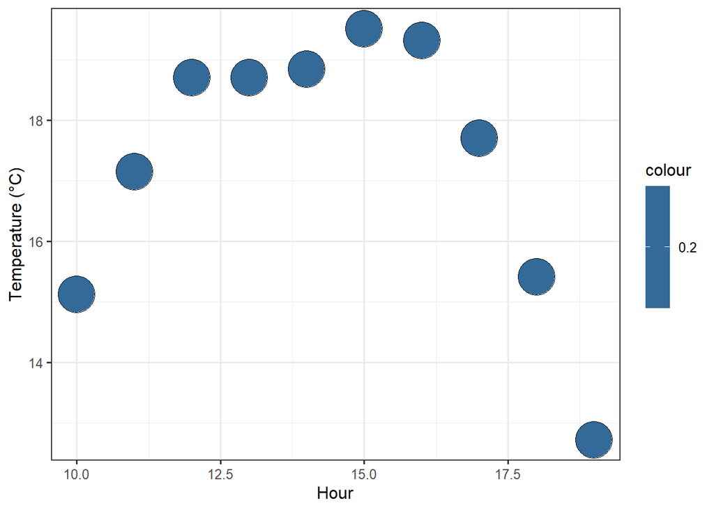

```r
ggplot(WHGlong, aes(Hour, value)) +
  geom_point(aes(colour=0.2), size=12) +
  geom_point(shape = 1, size = 12,colour = "black") +
  ylab("Temperature (°C)") +
  theme_bw(base_size = 12)
```

- Convert the dataset back to the wide format

```r
WHGwide <- WHGlong %>% pivot_wider(names_from = name)
WHGwide
```

```
## # A tibble: 10 × 6
##     Year Month   Day  Hour Temp_gaps  Temp
##    <int> <int> <int> <int>     <dbl> <dbl>
##  1  2008     3     3    10      15.1  15.1
##  2  2008     3     3    11      17.2  17.2
##  3  2008     3     3    12      18.7  18.7
##  4  2008     3     3    13      18.7  18.7
##  5  2008     3     3    14      18.8  18.8
##  6  2008     3     3    15      19.5  19.5
##  7  2008     3     3    16      19.3  19.3
##  8  2008     3     3    17      17.7  17.7
##  9  2008     3     3    18      15.4  15.4
## 10  2008     3     3    19      12.7  12.7
```

- Select only the following columns: Year, Month, Day and Temp

```r
WHG %>% select(c(Year, Month, Day, Temp))
```

```
## # A tibble: 10 × 4
##     Year Month   Day  Temp
##    <int> <int> <int> <dbl>
##  1  2008     3     3  15.1
##  2  2008     3     3  17.2
##  3  2008     3     3  18.7
##  4  2008     3     3  18.7
##  5  2008     3     3  18.8
##  6  2008     3     3  19.5
##  7  2008     3     3  19.3
##  8  2008     3     3  17.7
##  9  2008     3     3  15.4
## 10  2008     3     3  12.7
```

- Sort the dataset by the Temp column, in descending order

```r
WHG %>% arrange(desc(Temp))
```

```
## # A tibble: 10 × 6
##     Year Month   Day  Hour Temp_gaps  Temp
##    <int> <int> <int> <int>     <dbl> <dbl>
##  1  2008     3     3    15      19.5  19.5
##  2  2008     3     3    16      19.3  19.3
##  3  2008     3     3    14      18.8  18.8
##  4  2008     3     3    12      18.7  18.7
##  5  2008     3     3    13      18.7  18.7
##  6  2008     3     3    17      17.7  17.7
##  7  2008     3     3    11      17.2  17.2
##  8  2008     3     3    18      15.4  15.4
##  9  2008     3     3    10      15.1  15.1
## 10  2008     3     3    19      12.7  12.7
```

1. For the Winter_hours_gaps dataset, write a for loop to convert all temperatures (Temp column) to degrees Fahrenheit

```r
Temp <- Winters_hours_gaps$Temp[183:213] # JDay for July

for (i in Temp)
{
  Fahrenheit <- i * 1.8 + 32
  print(Fahrenheit)
}
```

```
## [1] 57.9362
## [1] 56.3828
## [1] 56.0354
## [1] 54.8654
## [1] 46.481
## [1] 44.7188
## [1] 44.2184
## [1] 45.3074
## [1] 53.078
## [1] 59.7884
## [1] 64.0328
## [1] 68.1422
## [1] 68.5274
## [1] 70.2014
## [1] 68.7848
```

[output cut: 16 more lines]

2. Execute the same operation with a function from the apply family

```r
x <- Winters_hours_gaps$Temp[183:213]

fahrenheit <- function(x)
  x * 1.8 + 32

sapply(x, fahrenheit)
```

```
##  [1] 57.9362 56.3828 56.0354 54.8654 46.4810 44.7188 44.2184 45.3074 53.0780
## [10] 59.7884 64.0328 68.1422 68.5274 70.2014 68.7848 69.4706 70.5434 68.3132
## [19] 62.6612 57.5924 54.9518 52.5092 51.1484 52.6406 57.0740 56.9876 49.2044
## [28] 47.2442 46.5710 46.3460 44.8556
```

3. Now use the tidyverse function mutate to achieve the same outcome

```r
WHG_F <- WHG %>% mutate(Temp_F = Temp * 1.8 + 32)
WHG_F
```

```
## # A tibble: 10 × 7
##     Year Month   Day  Hour Temp_gaps  Temp Temp_F
##    <int> <int> <int> <int>     <dbl> <dbl>  <dbl>
##  1  2008     3     3    10      15.1  15.1   59.2
##  2  2008     3     3    11      17.2  17.2   62.9
##  3  2008     3     3    12      18.7  18.7   65.7
##  4  2008     3     3    13      18.7  18.7   65.7
##  5  2008     3     3    14      18.8  18.8   65.9
##  6  2008     3     3    15      19.5  19.5   67.1
##  7  2008     3     3    16      19.3  19.3   66.8
##  8  2008     3     3    17      17.7  17.7   63.9
##  9  2008     3     3    18      15.4  15.4   59.7
## 10  2008     3     3    19      12.7  12.7   54.9
```

# 10 Chapter 10: Getting temperature data

## 10.1 *Exercises on getting temperature data*

1. Choose a location of interest and find the 25 closest weather stations using the handle_gsod function

```r
library(chillR)
station_list_Rochester <-handle_gsod(action="list_stations",
                          location=c(-77.60, 43.15),
                          time_interval=c(1990,2020))
library(magrittr)
require(kableExtra)

kable(station_list_Rochester) %>%
  kable_styling("striped", position = "left", font_size = 8)
```

| chillR_code | STATION.NAME | CTRY | Lat | Long | BEGIN | END | Distance | Overlap_years | Perc_interval_covered |
| --- | --- | --- | --- | --- | --- | --- | --- | --- | --- |
| 72529014768 | GREATER ROCHESTER INTERNATIONAL AP | US | 43.117 | -77.675 | 19730101 | 20241103 | 7.11 | 31.00 | 100 |
| 99999914768 | ROCHESTER MONROE CO ARPT | US | 43.117 | -77.677 | 19480101 | 19721231 | 7.25 | 0.00 | 0 |
| 72529599999 | ROCHESTER COAST GUARD LIGHT STAT | US | 43.250 | -77.600 | 19760926 | 19960701 | 11.13 | 6.50 | 21 |
| 99800999999 | ROCHESTER | US | 43.250 | -77.583 | 20080101 | 20241102 | 11.22 | 13.00 | 42 |
| 99826799999 | ROCHESTER | US | 43.269 | -77.626 | 20100101 | 20210114 | 13.41 | 11.00 | 35 |
| 99719099999 | LAKE ONTARIO BUOY - 20NM NORTH NORTHEAST | US | 43.620 | -77.410 | 20080517 | 20081125 | 54.53 | 0.53 | 2 |
| 72498899999 | DANSVILLE MUNI | US | 42.571 | -77.713 | 20010811 | 20031231 | 65.11 | 2.39 | 8 |
| 72523094704 | DANSVILLE/MUNICIPAL | US | 42.571 | -77.713 | 19730101 | 19850131 | 65.11 | 0.00 | 0 |
| 99999994704 | DANSVILLE MUNI AP | US | 42.571 | -77.713 | 19490101 | 20001101 | 65.11 | 10.84 | 35 |
| 72498894704 | DANSVILLE MUNICIPAL ARPT | US | 42.570 | -77.714 | 20010102 | 20241030 | 65.23 | 20.00 | 65 |
| 72523099999 | DANSVILLE MUNICIPAL | US | 42.567 | -77.717 | 20020418 | 20041014 | 65.60 | 2.49 | 8 |
| 72519454778 | PENN YAN AIRPORT | US | 42.644 | -77.053 | 20060101 | 20241103 | 71.85 | 15.00 | 48 |
| 9999994727 | GENEVA SAMPSON AFB | US | 42.750 | -76.900 | 19520102 | 19560624 | 72.36 | 0.00 | 0 |
| 72519499999 | PENN YAN | US | 42.633 | -77.050 | 19990114 | 20051231 | 72.97 | 6.97 | 22 |
| 71430099999 | POINT PETRE (AUT) ONT | CA | 43.833 | -77.150 | 19770611 | 20241102 | 84.27 | 31.00 | 100 |
| 71626899999 | PT PETRE | CA | 43.833 | -77.150 | 19770701 | 19800625 | 84.27 | 0.00 | 0 |
| 72626899999 | POINT PETRE (MARS) | CA | 43.833 | -77.150 | 19750905 | 19770630 | 84.27 | 0.00 | 0 |
| 99596099999 | PRINCE EDWARD PT | CA | 43.790 | -76.870 | 19911018 | 20081123 | 92.49 | 17.10 | 55 |
| 99798999999 | OLCOTT HARBOR | US | 43.333 | -78.717 | 20080101 | 20241102 | 92.85 | 13.00 | 42 |
| 72519599999 | OSWEGO COAST GUARD STATION | US | 43.470 | -76.520 | 19760926 | 19960701 | 94.46 | 6.50 | 21 |
| 99726499999 | 9052030 - OSWEGO NY | US | 43.460 | -76.510 | 20041122 | 20241102 | 94.81 | 16.11 | 52 |
| 99999914733 | BUFFALO BUFFALO ARPT | US | 42.941 | -78.736 | 19720101 | 19721231 | 95.30 | 0.00 | 0 |
| 72528014733 | BUFFALO NIAGARA INTERNATIONAL AIRPOR | US | 42.940 | -78.736 | 19420201 | 20241103 | 95.33 | 31.00 | 100 |
| 71431099999 | COBOURG (AUT) ONT | CA | 43.950 | -78.167 | 19770611 | 20241102 | 100.12 | 31.00 | 100 |
| 71626699999 | COBOURG | CA | 43.950 | -78.167 | 19770701 | 19800809 | 100.12 | 0.00 | 0 |

```r
station_list_Rochester
```

```
## # A tibble: 25 × 10
##    chillR_code STATION.NAME             CTRY    Lat  Long  BEGIN    END Distance
##    <chr>       <chr>                    <chr> <dbl> <dbl>  <int>  <int>    <dbl>
##  1 72529014768 GREATER ROCHESTER INTER… US     43.1 -77.7 1.97e7 2.02e7     7.11
##  2 99999914768 ROCHESTER MONROE CO ARPT US     43.1 -77.7 1.95e7 1.97e7     7.25
##  3 72529599999 ROCHESTER COAST GUARD L… US     43.2 -77.6 1.98e7 2.00e7    11.1
##  4 99800999999 ROCHESTER                US     43.2 -77.6 2.01e7 2.02e7    11.2
##  5 99826799999 ROCHESTER                US     43.3 -77.6 2.01e7 2.02e7    13.4
##  6 99719099999 LAKE ONTARIO BUOY - 20N… US     43.6 -77.4 2.01e7 2.01e7    54.5
##  7 72498899999 DANSVILLE MUNI           US     42.6 -77.7 2.00e7 2.00e7    65.1
##  8 72523094704 DANSVILLE/MUNICIPAL      US     42.6 -77.7 1.97e7 1.99e7    65.1
##  9 99999994704 DANSVILLE MUNI AP        US     42.6 -77.7 1.95e7 2.00e7    65.1
## 10 72498894704 DANSVILLE MUNICIPAL ARPT US     42.6 -77.7 2.00e7 2.02e7    65.2
## # ℹ 15 more rows
## # ℹ 2 more variables: Overlap_years <dbl>, Perc_interval_covered <dbl>
```

1. Download weather data for the most promising station on the list

```r
weather <- handle_gsod(action = "download_weather",
                       location = station_list_Rochester$chillR_code[1],
                       time_interval = c(1990, 2020))
```

```
## Loading data for 31 years from station 'GREATER ROCHESTER INTERNATIONAL AP'
## ================================================================================
```

```r
weather[[1]][1:20,]
```

```
##        STATION       DATE LATITUDE LONGITUDE ELEVATION
## 1  72529014768 1990-01-01 43.11723 -77.67539     164.5
## 2  72529014768 1990-01-02 43.11723 -77.67539     164.5
## 3  72529014768 1990-01-03 43.11723 -77.67539     164.5
## 4  72529014768 1990-01-04 43.11723 -77.67539     164.5
## 5  72529014768 1990-01-05 43.11723 -77.67539     164.5
## 6  72529014768 1990-01-06 43.11723 -77.67539     164.5
## 7  72529014768 1990-01-07 43.11723 -77.67539     164.5
## 8  72529014768 1990-01-08 43.11723 -77.67539     164.5
## 9  72529014768 1990-01-09 43.11723 -77.67539     164.5
## 10 72529014768 1990-01-10 43.11723 -77.67539     164.5
## 11 72529014768 1990-01-11 43.11723 -77.67539     164.5
## 12 72529014768 1990-01-12 43.11723 -77.67539     164.5
## 13 72529014768 1990-01-13 43.11723 -77.67539     164.5
## 14 72529014768 1990-01-14 43.11723 -77.67539     164.5
```

[output cut: 90 more lines]

1. Convert the weather data into chillR format

```r
cleaned_weather <- handle_gsod(weather)

cleaned_weather[[1]][1:20,]
```

```
##          Date Year Month Day    Tmin   Tmax  Tmean  Prec
## 1  1990-01-01 1990     1   1  -3.889  6.722 -0.500 5.080
## 2  1990-01-02 1990     1   2  -3.278  2.222 -1.056 1.016
## 3  1990-01-03 1990     1   3  -2.778  6.722  1.000 0.000
## 4  1990-01-04 1990     1   4   3.278  8.278  6.500 0.508
## 5  1990-01-05 1990     1   5  -2.222  8.889  0.556 2.032
## 6  1990-01-06 1990     1   6  -7.222  1.722 -3.222 0.000
## 7  1990-01-07 1990     1   7  -9.389  6.111 -1.667 0.508
## 8  1990-01-08 1990     1   8  -1.722  6.722  2.944 0.000
## 9  1990-01-09 1990     1   9   1.111  7.222  2.611 0.000
## 10 1990-01-10 1990     1  10   0.611  5.000  2.500 2.032
## 11 1990-01-11 1990     1  11   0.000  4.389  1.278 2.032
## 12 1990-01-12 1990     1  12  -6.111  4.389 -1.833 2.032
## 13 1990-01-13 1990     1  13 -12.222  1.111 -8.722 3.048
## 14 1990-01-14 1990     1  14  -7.778 -3.889 -4.722 0.000
## 15 1990-01-15 1990     1  15  -3.889  6.111  2.056 0.254
## 16 1990-01-16 1990     1  16   2.778 10.000  5.278 0.000
## 17 1990-01-17 1990     1  17   2.222 12.778  7.444 1.016
## 18 1990-01-18 1990     1  18   2.222 13.278  8.222 8.890
## 19 1990-01-19 1990     1  19  -4.389  2.222 -1.556 1.016
## 20 1990-01-20 1990     1  20  -5.000  1.722 -2.056 0.000
```

```r
dir.create("data_New_York")
write.csv(station_list_Rochester,
          "data_New_York/station_list_Rochester.csv",
          row.names = FALSE)
write.csv(weather[[1]],
          "data_New_York/Rochester_weather.csv",
          row.names = FALSE)
write.csv(cleaned_weather[[1]],
          "data_New_York/Rochester_chillR_weather.csv",
          row.names = FALSE)
```

# 11 Chapter 11: Getting temperature data

## 11.1 *Exercises on getting temperature data*

1. Use chillR functions to find out how many gaps you have in this dataset (even if you have none, please still follow all further steps)

```r
Rochester <- read.csv("data_New_York/Rochester_chillR_weather.csv")

Rochester_QC <- fix_weather(Rochester)$QC
```

2. Create a list of the 25 closest weather stations using the handle_gsod function

```r
station_list <- handle_gsod(action="list_stations",
                            location=c(-77.60, 43.15),
                              time_interval=c(1990,2020))

station_list
```

```
## # A tibble: 25 × 10
##    chillR_code STATION.NAME             CTRY    Lat  Long  BEGIN    END Distance
##    <chr>       <chr>                    <chr> <dbl> <dbl>  <int>  <int>    <dbl>
##  1 72529014768 GREATER ROCHESTER INTER… US     43.1 -77.7 1.97e7 2.02e7     7.11
##  2 99999914768 ROCHESTER MONROE CO ARPT US     43.1 -77.7 1.95e7 1.97e7     7.25
##  3 72529599999 ROCHESTER COAST GUARD L… US     43.2 -77.6 1.98e7 2.00e7    11.1
##  4 99800999999 ROCHESTER                US     43.2 -77.6 2.01e7 2.02e7    11.2
##  5 99826799999 ROCHESTER                US     43.3 -77.6 2.01e7 2.02e7    13.4
##  6 99719099999 LAKE ONTARIO BUOY - 20N… US     43.6 -77.4 2.01e7 2.01e7    54.5
##  7 72498899999 DANSVILLE MUNI           US     42.6 -77.7 2.00e7 2.00e7    65.1
##  8 72523094704 DANSVILLE/MUNICIPAL      US     42.6 -77.7 1.97e7 1.99e7    65.1
##  9 99999994704 DANSVILLE MUNI AP        US     42.6 -77.7 1.95e7 2.00e7    65.1
## 10 72498894704 DANSVILLE MUNICIPAL ARPT US     42.6 -77.7 2.00e7 2.02e7    65.2
## # ℹ 15 more rows
## # ℹ 2 more variables: Overlap_years <dbl>, Perc_interval_covered <dbl>
```

```r
print(station_list, n = 26)
```

```
## # A tibble: 25 × 10
##    chillR_code STATION.NAME             CTRY    Lat  Long  BEGIN    END Distance
##    <chr>       <chr>                    <chr> <dbl> <dbl>  <int>  <int>    <dbl>
##  1 72529014768 GREATER ROCHESTER INTER… US     43.1 -77.7 1.97e7 2.02e7     7.11
##  2 99999914768 ROCHESTER MONROE CO ARPT US     43.1 -77.7 1.95e7 1.97e7     7.25
##  3 72529599999 ROCHESTER COAST GUARD L… US     43.2 -77.6 1.98e7 2.00e7    11.1
##  4 99800999999 ROCHESTER                US     43.2 -77.6 2.01e7 2.02e7    11.2
##  5 99826799999 ROCHESTER                US     43.3 -77.6 2.01e7 2.02e7    13.4
##  6 99719099999 LAKE ONTARIO BUOY - 20N… US     43.6 -77.4 2.01e7 2.01e7    54.5
##  7 72498899999 DANSVILLE MUNI           US     42.6 -77.7 2.00e7 2.00e7    65.1
##  8 72523094704 DANSVILLE/MUNICIPAL      US     42.6 -77.7 1.97e7 1.99e7    65.1
##  9 99999994704 DANSVILLE MUNI AP        US     42.6 -77.7 1.95e7 2.00e7    65.1
## 10 72498894704 DANSVILLE MUNICIPAL ARPT US     42.6 -77.7 2.00e7 2.02e7    65.2
## 11 72523099999 DANSVILLE MUNICIPAL      US     42.6 -77.7 2.00e7 2.00e7    65.6
## 12 72519454778 PENN YAN AIRPORT         US     42.6 -77.1 2.01e7 2.02e7    71.8
## 13 9999994727  GENEVA SAMPSON AFB       US     42.8 -76.9 1.95e7 1.96e7    72.4
## 14 72519499999 PENN YAN                 US     42.6 -77.0 2.00e7 2.01e7    73.0
## 15 71430099999 POINT PETRE (AUT)  ONT   CA     43.8 -77.2 1.98e7 2.02e7    84.3
## 16 71626899999 PT PETRE                 CA     43.8 -77.2 1.98e7 1.98e7    84.3
## 17 72626899999 POINT PETRE (MARS)       CA     43.8 -77.2 1.98e7 1.98e7    84.3
## 18 99596099999 PRINCE EDWARD PT         CA     43.8 -76.9 1.99e7 2.01e7    92.5
## 19 99798999999 OLCOTT HARBOR            US     43.3 -78.7 2.01e7 2.02e7    92.8
## 20 72519599999 OSWEGO COAST GUARD STAT… US     43.5 -76.5 1.98e7 2.00e7    94.5
## 21 99726499999 9052030 - OSWEGO  NY     US     43.5 -76.5 2.00e7 2.02e7    94.8
## 22 99999914733 BUFFALO BUFFALO ARPT     US     42.9 -78.7 1.97e7 1.97e7    95.3
## 23 72528014733 BUFFALO NIAGARA INTERNA… US     42.9 -78.7 1.94e7 2.02e7    95.3
## 24 71431099999 COBOURG (AUT)  ONT       CA     44.0 -78.2 1.98e7 2.02e7   100.
## 25 71626699999 COBOURG                  CA     44.0 -78.2 1.98e7 1.98e7   100.
## # ℹ 2 more variables: Overlap_years <dbl>, Perc_interval_covered <dbl>
```

3. Identify suitable weather stations for patching gaps

#download stations number 4, 5, and 10 these will be used to patch the gaps

4. Download weather data for promising stations, convert them to chillR format and compile them in a list

```r
patch_weather<-
  handle_gsod(action = "download_weather",
              location = as.character(station_list$chillR_code[c(4,5,10)]),
              time_interval = c(1990,2020)) %>%
  handle_gsod()
```

[output not shown]

5. Use the patch_daily_temperatures function to fill gaps

```r
patched <- patch_daily_temperatures(weather = Rochester,
                                    patch_weather = patch_weather)


patched$statistics[[1]]
```

```
##      mean_bias stdev_bias filled gaps_remain
## Tmin    -0.213      2.319      0           0
## Tmax    -0.521      2.143      0           1
```

```r
patched$statistics[[2]]
```

```
##      mean_bias stdev_bias filled gaps_remain
## Tmin    -2.944      2.520      0           0
## Tmax     2.408      2.624      0           1
```

```r
patched$statistics[[3]]
```

```
##      mean_bias stdev_bias filled gaps_remain
## Tmin    -2.238      2.316      0           0
## Tmax     2.325      2.761      0           1
```

#set minimum quality criteria

```r
patched <- patch_daily_temperatures(weather = Rochester,
                                    patch_weather = patch_weather,
                                    max_mean_bias = 1,
                                    max_stdev_bias = 2)

patched$statistics[[1]]
```

```
##      mean_bias stdev_bias filled gaps_remain
## Tmin    -0.213      2.319      0           0
## Tmax    -0.521      2.143      0           1
```

```r
patched$statistics[[2]]
```

```
##      mean_bias stdev_bias filled gaps_remain
## Tmin    -2.944      2.520      0           0
## Tmax     2.408      2.624      0           1
```

```r
patched$statistics[[3]]
```

```
##      mean_bias stdev_bias filled gaps_remain
## Tmin    -2.238      2.316      0           0
## Tmax     2.325      2.761      0           1
```

6. Investigate the results - have all gaps been filled?

```r
post_patch_stats <- fix_weather(patched)$QC

post_patch_stats
```

```
##       Season End_year Season_days Data_days Missing_Tmin Missing_Tmax
## 1  1989/1990     1990         365       365            0            0
## 2  1990/1991     1991         365       365            0            0
## 3  1991/1992     1992         366       366            0            0
## 4  1992/1993     1993         365       365            0            0
## 5  1993/1994     1994         365       365            0            0
## 6  1994/1995     1995         365       365            0            0
## 7  1995/1996     1996         366       366            0            0
## 8  1996/1997     1997         365       365            0            0
## 9  1997/1998     1998         365       365            0            0
## 10 1998/1999     1999         365       365            0            0
## 11 1999/2000     2000         366       366            0            0
## 12 2000/2001     2001         365       365            0            0
## 13 2001/2002     2002         365       365            0            1
## 14 2002/2003     2003         365       365            0            0
```

[output cut: 49 more lines]

7. If necessary, repeat until you have a dataset you can work with in further analyses

```r
Rochester_weather<-fix_weather(patched)

patched_monthly <- patch_daily_temps(weather = Rochester,
                                     patch_weather = patch_weather,
                                     max_mean_bias = 1,
                                     max_stdev_bias = 2,
                                     time_interval = "month")
```

#saving the data for later

```r
monthly_bias_fixed <- fix_weather(patched_monthly)

write.csv(monthly_bias_fixed$weather,
          "data_New_York/Rochester_weather.csv")
```

# 12 Chapter 12: Generating temperature scenarios

## 12.1 *Exercises on getting temperature data*

1. For the location you chose for your earlier analyses, use chillR’s weather generator to produce 100 years of synthetic temperature data.

```r
library(chillR)
library(tidyverse)

Rochester <- read.csv('data_New_York/Rochester_weather.csv')

Temp <- Rochester %>%
  temperature_generation(years = c(1998,2009),
                         sim_years = c(2001,2100))

library(dplyr)
library(magrittr)

Temperatures <- Rochester %>%
  select(Year, Month, Day, Tmin, Tmax) %>%
  filter(Year %in% 1998:2009) %>%
  cbind(Data_source = "observed") %>%
  rbind(
    Temp[[1]] %>% select(c(Year,
                           Month,
                           Day,
                           Tmin,
                           Tmax)) %>%
      cbind(Data_source = "simulated")
    ) %>%
  mutate(Date = as.Date(ISOdate(2000,
                                Month,
                                Day)))

ggplot(data = Temperatures,
       aes(Date,
           Tmin)) +
  geom_smooth(aes(colour = factor(Year))) +
  facet_wrap(vars(Data_source)) +
  theme_bw(base_size = 20) +
  theme(legend.position = "none") +
  scale_x_date(date_labels = "%b")

ggplot(data = Temperatures,
       aes(Date,
           Tmax)) +
  geom_smooth(aes(colour = factor(Year))) +
  facet_wrap(vars(Data_source)) +
  theme_bw(base_size = 20) +
  theme(legend.position = "none") +
  scale_x_date(date_labels = "%b")
```

2. Calculate winter chill (in Chill Portions) for your synthetic weather, and illustrate your results as histograms and cumulative distributions.

```r
library(chillR)
library(tidyverse)

Rochester <- read.csv('data_New_York/Rochester_weather.csv')

Temp <- Rochester %>%
  temperature_generation(years = c(1998,2009),
                         sim_years = c(2001,2100))

library(dplyr)
library(magrittr)

Temperatures <- Rochester %>%
  select(Year, Month, Day, Tmin, Tmax) %>%
  filter(Year %in% 1998:2009) %>%
  cbind(Data_source = "observed") %>%
  rbind(
    Temp[[1]] %>% select(c(Year,
                           Month,
                           Day,
                           Tmin,
                           Tmax)) %>%
      cbind(Data_source = "simulated")
    ) %>%
  mutate(Date = as.Date(ISOdate(2000,
                                Month,
                                Day)))

chill_observed <- Temperatures %>%
  filter(Data_source == "observed") %>%
  stack_hourly_temps(latitude = 43.15) %>%
  chilling(Start_JDay = 305,
           End_JDay = 59)

chill_simulated <- Temperatures %>%
  filter(Data_source == "simulated") %>%
  stack_hourly_temps(latitude = 43.15) %>%
  chilling(Start_JDay = 305,
           End_JDay = 59)

chill_comparison <-
  cbind(chill_observed,
        Data_source = "observed") %>%
  rbind(cbind(chill_simulated,
              Data_source = "simulated"))

chill_comparison_full_seasons <-
  chill_comparison %>%
  filter(Perc_complete == 100)

ggplot(chill_comparison_full_seasons,
       aes(x = Chill_portions)) +
  geom_histogram(binwidth = 1,
                 aes(fill = factor(Data_source))) +
  theme_bw(base_size = 20) +
  labs(fill = "Data source") +
  xlab("Chill accumulation (Chill Portions)") +
  ylab("Frequency")

chill_simulations <-
  chill_comparison_full_seasons %>%
  filter(Data_source == "simulated")

ggplot(chill_simulations,
       aes(x = Chill_portions)) +
  stat_ecdf(geom = "step",
            lwd = 1.5,
            col = "blue") +
  ylab("Cumulative probability") +
  xlab("Chill accumulation (in Chill Portions)") +
  theme_bw(base_size = 20)
```

3. Produce similar plots for the number of freezing hours (<0°C) in April (or October, if your site is in the Southern Hemisphere) for your location of interest.

```r
library(chillR)
library(tidyverse)

Rochester <- read.csv('data_New_York/Rochester_weather.csv')

Temp <- Rochester %>%
  temperature_generation(years = c(1998,2009),
                         sim_years = c(2001,2100))

library(dplyr)
library(magrittr)

Temperatures <- Rochester %>%
  select(Year, Month, Day, Tmin, Tmax) %>%
  filter(Year %in% 1998:2009) %>%
  cbind(Data_source = "observed") %>%
  rbind(
    Temp[[1]] %>% select(c(Year,
                           Month,
                           Day,
                           Tmin,
                           Tmax)) %>%
      cbind(Data_source = "simulated")
    ) %>%
  mutate(Date = as.Date(ISOdate(2000,
                                Month,
                                Day)))
df <- data.frame(
  lower =  c(-1000,    0),
  upper =  c(    0, 1000),
  weight = c(    1,    0))

freezing_hours <- function(x) step_model(x,df)

chill_observed <- Temperatures %>%
  filter(Data_source == "observed") %>%
  stack_hourly_temps(latitude = 43.15) %>%
  tempResponse(Start_JDay = 91,
               End_JDay = 120,
               models = list(Frost = freezing_hours,
                             Chill_portions = Dynamic_Model,
                             GDH = GDH))

chill_simulated <- Temperatures %>%
  filter(Data_source == "simulated") %>%
  stack_hourly_temps(latitude = 43.15) %>%
  tempResponse(Start_JDay = 91,
               End_JDay = 120,
               models=list(Frost = freezing_hours,
                           Chill_portions = Dynamic_Model,
                           GDH = GDH))

chill_comparison <-
  cbind(chill_observed,
        Data_source = "observed") %>%
  rbind(cbind(chill_simulated,
              Data_source = "simulated"))

chill_comparison_full_seasons <-
  chill_comparison %>%
  filter(Perc_complete == 100)

ggplot(chill_comparison_full_seasons,
       aes(x = Frost)) +
  geom_histogram(binwidth = 25,
                 aes(fill = factor(Data_source))) +
  theme_bw(base_size = 10) +
  labs(fill = "Data source") +
  xlab("Frost incidence during April (hours)") +
  ylab("Frequency")

chill_simulations <-
  chill_comparison_full_seasons %>%
  filter(Data_source == "simulated")

ggplot(chill_simulations,
       aes(x = Frost)) +
  stat_ecdf(geom = "step",
            lwd = 1.5,
            col = "blue") +
  ylab("Cumulative probability") +
  xlab("Frost incidence during April (hours)") +
  theme_bw(base_size = 20)
```

# 13 Chapter 14: Generating historic temperature scenarios

## 13.1 *Exercises on historic temperature scenarios*

1. For the location you chose for previous exercises, produce historic temperature scenarios representing several years of the historic record (your choice).

```r
library(chillR)
library(magrittr)
require(kableExtra)

# downloading weather station list for the vicinity of Rochester
station_list <- handle_gsod(action = "list_stations",
                            location=c(-77.60, 43.15))

# downloading weather data for Greater Rochester International AP and convert it to chillR format
Rochester_weather <- handle_gsod(action = "download_weather",
                            location = station_list$chillR_code[1],
                            time_interval = c(1973,2019)) %>%
  handle_gsod()

# check record for missing data
fix_weather(Rochester_weather$'GREATER ROCHESTER INTERNATIONAL AP')$QC

Rochester_patched <- patch_daily_temperatures(
  weather = Rochester_weather$'GREATER ROCHESTER INTERNATIONAL AP',
  patch_weather = list(KA_weather))

fix_weather(Rochester_patched)$QC

# interpolating these gaps now

Rochester<-fix_weather(Rochester_patched)

Rochester_temps<-Rochester$weather

scenario_1980 <- temperature_scenario_from_records(weather = Rochester_temps,
                                                   year = 1980)

scenario_1980$'1980'$data

#what could have happened in 1980 not what happpened

temps_1980 <- temperature_generation(weather = Rochester_temps,
                                     years = c(1973, 2019),
                                     sim_years = c(2001, 2100),
                                     temperature_scenario = scenario_1980)

scenario_1996 <- temperature_scenario_from_records(weather = Rochester_temps,
                                                   year = 1996)
scenario_1996$'1996'$data

relative_scenario <- temperature_scenario_baseline_adjustment(
  baseline = scenario_1996,
  temperature_scenario = scenario_1980)

# error message here

temps_1980 <- temperature_generation(weather = Rochester_temps,
                                     years = c(1973, 2019),
                                     sim_years = c(2001, 2100),
                                     temperature_scenario = relative_scenario)

all_past_scenarios <- temperature_scenario_from_records(
  weather = Rochester_temps,
  year = c(1980,
           1990,
           2000,
           2010))

adjusted_scenarios <- temperature_scenario_baseline_adjustment(
  baseline = scenario_1996,
  temperature_scenario = all_past_scenarios)
```

```r
all_past_scenario_temps <- temperature_generation(
  weather = Rochester_temps,
  years = c(1973,2019),
  sim_years = c(2001,2100),
  temperature_scenario = adjusted_scenarios)
```

```r
frost_model <- function(x)
  step_model(x,
             data.frame(
               lower=c(-1000, 0),
               upper=c(0, 1000),
               weight=c(1, 0)))

models <- list(Chill_Portions = Dynamic_Model,
               GDH = GDH,
               Frost_H = frost_model)






chill_hist_scenario_list <- tempResponse_daily_list(all_past_scenario_temps,
                                                    latitude = 43.15,
                                                    Start_JDay = 305,
                                                    End_JDay = 59,
                                                    models = models)
```

2. Produce chill distributions for these scenarios and plot them.

```r
scenarios <- names(chill_hist_scenario_list)[1:4]


all_scenarios <- chill_hist_scenario_list[[scenarios[1]]] %>%
  mutate(scenario = as.numeric(scenarios[1]))


for (sc in scenarios[2:4])
 all_scenarios <- all_scenarios %>%
  rbind(chill_hist_scenario_list[[sc]] %>%
          cbind(
            scenario=as.numeric(sc))
        ) %>%
  filter(Perc_complete == 100)

# Let's compute the actual 'observed' chill for comparison
actual_chill <- tempResponse_daily_list(Rochester_temps,
                                        latitude = 43.15,
                                        Start_JDay = 305,
                                        End_JDay = 59,
                                        models)[[1]] %>%
  filter(Perc_complete == 100)

ggplot(data = all_scenarios,
       aes(scenario,
           Chill_Portions,
           fill = factor(scenario))) +
  geom_violin(draw_quantiles = c(0.25, 0.5, 0.75)) +
  ylab("Chill accumulation (Chill Portions)") +
  xlab("Scenario year") +
  theme_bw(base_size = 10) +
  ylim(c(0,90)) +
  geom_point(data = actual_chill,
             aes(End_year,
                 Chill_Portions,
                 fill = "blue"),
             col = "blue",
             show.legend = FALSE) +
  scale_fill_discrete(name = "Scenario",
                      breaks = unique(all_scenarios$scenario))


temperature_means <-
  data.frame(Year = min(Rochester_temps$Year):max(Rochester_temps$Year),
             Tmin = aggregate(Rochester_temps$Tmin,
                              FUN = "mean",
                              by = list(Rochester_temps$Year))[,2],
             Tmax=aggregate(Rochester_temps$Tmax,
                            FUN = "mean",
                            by = list(Rochester_temps$Year))[,2]) %>%
  mutate(runn_mean_Tmin = runn_mean(Tmin,15),
         runn_mean_Tmax = runn_mean(Tmax,15))


Tmin_regression <- lm(Tmin ~ Year,
                      temperature_means)

Tmax_regression <- lm(Tmax ~ Year,
                      temperature_means)

temperature_means <- temperature_means %>%
  mutate(regression_Tmin = Tmin_regression$coefficients[1]+
           Tmin_regression$coefficients[2]*temperature_means$Year,
         regression_Tmax = Tmax_regression$coefficients[1]+
           Tmax_regression$coefficients[2]*temperature_means$Year
  )


ggplot(temperature_means,
       aes(Year,
           Tmin)) +
  geom_point() +
  geom_line(data = temperature_means,
            aes(Year,
                runn_mean_Tmin),
            lwd = 2,
            col = "blue") +
  geom_line(data = temperature_means,
            aes(Year,
                regression_Tmin),
            lwd = 2,
            col = "red") +
  theme_bw(base_size = 15) +
  ylab("Mean monthly minimum temperature (°C)")

ggplot(temperature_means,
       aes(Year,
           Tmax)) +
  geom_point() +
  geom_line(data = temperature_means,
            aes(Year,
                runn_mean_Tmax),
            lwd = 2,
            col = "blue") +
  geom_line(data = temperature_means,
            aes(Year,
                regression_Tmax),
            lwd = 2,
            col = "red") +
  theme_bw(base_size = 15) +
  ylab("Mean monthly maximum temperature (°C)")
```

# 14 Chapter 15: Future temperature scenarios

## 14.1 ***Exercises on future temperature scenarios**

1. Briefly describe the differences between the RCPs and the SSPs.

Representative Concentration Pathways (RCPs) are climate change scenarios to project future greenhouse gas concentrations.These pathways (or trajectories) describe future greenhouse gas concentrations (not emissions) and have been formally adopted by the IPCC. The pathways describe different climate change scenarios, all of which were considered possible depending on the amount of greenhouse gases (GHG) emitted in the years to come.

Shared Socioeconomic Pathways (SSPs) are climate change scenarios of projected socioeconomic global changes up to 2100 as defined in the IPCC Sixth Assessment Report on climate change in 2021.The SRES scenarios are “baseline” (or “reference”) scenarios, which means that they do not take into account any current or future measures to limit greenhouse gas (GHG) emissions.

A major difference between both models is that RCPs focus on Emissions and Radiative Forcing while SSPs emphasize Socioeconomic Pathways.In phenology SSPs integrate societal drivers, allowing phenologists to link temperature scenarios with land use changes, habitat fragmentation, or conservation efforts.

# 15 Chapter 16: Generating CMIP6 temperature scenarios

## 15.1 *Exercises on generating CMIP6 temperature scenarios*

1. Analyze the historic and future impact of climate change on two agroclimatic metrics of your choice, for the location you’ve chosen for your earlier analyses.

```r
require(chillR)
library(dplyr)
library(ecmwfr)
require(tidyverse)

#read Rochester_temps

Rochester_temps <- read_tab("C:/Users/Home/Documents/R Files/Trial Bookdown/data_New_York/Rochester_temps.csv")

location=c(-77.60, 43.15) #Rochester

area <- c(45, -79, 40, -71)


download_cmip6_ecmwfr(
  scenarios = c("ssp126", "ssp245", "ssp370", "ssp585"),
  area = area,
  key = 'e1bd6995-c569-4df1-bbe8-3549cb586e4a',
  model = 'default',
  frequency = 'monthly',
  variable = c('Tmin',  'Tmax'),
  year_start = 2015,
  year_end = 2100)

download_baseline_cmip6_ecmwfr(
  area = area,
  key = 'e1bd6995-c569-4df1-bbe8-3549cb586e4a',
  model = 'match_downloaded',
  frequency = 'monthly',
  variable = c('Tmin', 'Tmax'),
  year_start = 1986,
  year_end = 2014,
  month = 1:12)

download_baseline_cmip6_ecmwfr(
  area = area,
  key = 'e1bd6995-c569-4df1-bbe8-3549cb586e4a',
  model = 'match_downloaded',
  frequency = 'monthly',
  variable = c('Tmin', 'Tmax'),
  year_start = 1986,
  year_end = 2014,
  month = 1:12)

station <- data.frame(
  station_name = c("Rochester"),
  longitude = c(-77.60),
  latitude = c(43.15))

library(ncdf4)
library(PCICt)

extracted <- extract_cmip6_data(stations = station)

head(extracted$`ssp126_AWI-CM-1-1-MR`)

change_scenarios <-
  gen_rel_change_scenario(extracted,
                          scenarios = c(2050, 2085),
                          reference_period = c(1986:2014),
                          future_window_width = 30)
head(change_scenarios)

write.csv(change_scenarios, "C:/Users/Home/Documents/R Files/Trial Bookdown/data_New_York/all_change_scenarios.csv", row.names = FALSE)

change_scenarios <- read.csv("C:/Users/Home/Documents/R Files/Trial Bookdown/data_New_York/all_change_scenarios.csv")

scen_list <- convert_scen_information(change_scenarios)

scen_frame <- convert_scen_information(scen_list)

scen_list$Rochester$ssp126$`ACCESS-CM2`$'2050'


temps_1996 <- temperature_scenario_from_records(Rochester_temps,
                                                1996)
temps_2000 <- temperature_scenario_from_records(Rochester_temps,
                                                2000)
temps_1996
temps_2000

base <- temperature_scenario_baseline_adjustment(temps_1996,
                                                 temps_2000)

base


scen_list <- convert_scen_information(change_scenarios,
                                      give_structure = FALSE)

adjusted_list <- temperature_scenario_baseline_adjustment(base,
                                                          scen_list,
                   temperature_check_args =
                     list(scenario_check_thresholds = c(-5, 15)))


# temps <- temperature_generation(Rochester_temps,
#                                 years = c(1973, 2019),
#                                 sim_years = c(2001, 2100),
#                                 adjusted_list,
#                                 temperature_check_args =
#                                   list( scenario_check_thresholds = c(-5, 15)))
#
# save_temperature_scenarios(temps,
#                            "data_New_York/future_climate","Rochester_future")

# temps <- load_temperature_scenarios("data_New_Year/future_climate","Rochester_future_")


# now we have temperature scenarios

for(scen in 1:length(adjusted_list))
{
  if(!file.exists(paste0("C:/Users/Home/Documents/R Files/Trial Bookdown/data_New_York/future_climate/Rochester_future_",
                       scen,"_",
                       names(adjusted_list)[scen],".csv")) )
  {temp_temp <- temperature_generation(Rochester_temps,
                                   years = c(1973, 2019),
                                   sim_years = c(2001, 2100),
                                   adjusted_list[scen],
                                   temperature_check_args =
                                     list( scenario_check_thresholds = c(-5, 15)))
  write.csv(temp_temp[[1]],paste0("C:/Users/Home/Documents/R Files/Trial Bookdown/data_New_York/future_climate/Rochester_future_",scen,"_",names(adjusted_list)[scen],".csv"),
                             row.names=FALSE)
  print(paste("Processed object",scen,"of", length(adjusted_list)))


  }

}



temps <- load_temperature_scenarios("C:/Users/Home/Documents/R Files/Trial Bookdown/data_New_York/future_climate","Rochester_future_")

frost_model <- function(x)
  step_model(x,
             data.frame(
               lower = c(-1000, 0),
               upper = c(0, 1000),
               weight = c(1, 0)))

models <- list(Chill_Portions = Dynamic_Model,
               GDH = GDH,
               Frost_H = frost_model)

chill_future_scenario_list <-
  tempResponse_daily_list(temps,
                          latitude = 43.15,
                          Start_JDay = 305,
                          End_JDay = 59,
                          models = models)

chill_future_scenario_list <-
  lapply(chill_future_scenario_list,
         function(x) x %>%
           filter(Perc_complete == 100))

save_temperature_scenarios(chill_future_scenario_list,
                           "C:/Users/Home/Documents/R Files/Trial Bookdown/data_New_York/future_climate",
                           "Rochester_futurechill")

# this would be for spring frost, but we're not running this
chill_future_scenario_list_frost <-
  tempResponse_daily_list(temps,
                          latitude = 43.15,
                          Start_JDay = 75,
                          End_JDay = 120,
                          models = list(GDH = GDH,
                                        Frost_H = frost_model))

chill_future_scenario_list_frost <-
  lapply(chill_future_scenario_list_frost,
         function(x) x %>%
           filter(Perc_complete == 100))


save_temperature_scenarios(chill_future_scenario_list_frost,
                           "C:/Users/Home/Documents/R Files/Trial Bookdown/data_New_York/future_climate",
                           "Rochester_futurefrost")

# simulate for the observed record

Rochester_temps <- read_tab("C:/Users/Home/Documents/R Files/Trial Bookdown/data_New_York/Rochester_temps.csv")

observed_chill <- tempResponse_daily_list(Rochester_temps,
                                          latitude = 43.15,
                                          Start_JDay = 305,
                                          End_JDay = 59,
                                          models = models)

write.csv(observed_chill, "C:/Users/Home/Documents/R Files/Trial Bookdown/data_New_York/Rochester_observed_chill_305_59.csv")

# simulate chill for historic scenarios

hist_temps <- load_temperature_scenarios("C:/Users/Home/Documents/R Files/Trial Bookdown/data_New_York","all_past_temps")



chill_hist_scenario_list <- tempResponse_daily_list(hist_temps,
                                                    latitude = 43.15,
                                                    Start_JDay = 305,
                                                    End_JDay = 59,
                                                    models = models)

chill_hist_scenario_list <- lapply(chill_hist_scenario_list,
                                   function(x) x %>%
                                     filter(Perc_complete == 100))

save_temperature_scenarios(chill_hist_scenario_list,
                           "C:/Users/Home/Documents/R Files/Trial Bookdown/data_New_York/future_climate",
                           "Rochester_hist_chill_305_59")

chill_future_scenario_list <- load_temperature_scenarios("C:/Users/Home/Documents/R Files/Trial Bookdown/data_New_York/future_climate","Rochester_futurechill")
chill_hist_scenario_list<-load_temperature_scenarios("C:/Users/Home/Documents/R Files/Trial Bookdown/data_New_York","Rochester_hist_chill_305_59")
observed_chill <- read_tab("C:/Users/Home/Documents/R Files/Trial Bookdown/data_New_York/Rochester_observed_chill_305_59.csv")


# prepare for plotting

chills <- make_climate_scenario(
  metric_summary = chill_hist_scenario_list,
  caption = "Historical",
  historic_data = observed_chill,
  time_series = TRUE)

plot_climate_scenarios(
  climate_scenario_list = chills,
  metric = "Chill_Portions",
  metric_label = "Chill (Chill Portions)")


list_ssp <-
  strsplit(names(chill_future_scenario_list),
           '\\.') %>%
  map(2) %>%
  unlist()

list_gcm <-
  strsplit(names(chill_future_scenario_list), '\\.') %>%
  map(3) %>%
  unlist()

list_time <-
  strsplit(names(chill_future_scenario_list), '\\.') %>%
  map(4) %>%
  unlist()

SSPs <- c("ssp126", "ssp245", "ssp370", "ssp585")
Times <- c(2050, 2085)


for(SSP in SSPs)
  for(Time in Times)
  {

    # find all scenarios for the ssp and time
    chill <- chill_future_scenario_list[list_ssp == SSP &
                                          list_time == Time]
    names(chill) <- list_gcm[list_ssp == SSP &
                               list_time == Time]
    if(SSP == "ssp126") SSPcaption <- "SSP1"
    if(SSP == "ssp245") SSPcaption <- "SSP2"
    if(SSP == "ssp370") SSPcaption <- "SSP3"
    if(SSP == "ssp585") SSPcaption <- "SSP5"
    chills <- chill %>%
      make_climate_scenario(
        caption = c(SSPcaption,
                    Time),
        add_to = chills)
  }



info_chill <-
  plot_climate_scenarios(
    climate_scenario_list = chills,
    metric = "Chill_Portions",
    metric_label = "Chill (Chill Portions)",
    texcex = 1)

info_heat <-
  plot_climate_scenarios(
    climate_scenario_list = chills,
    metric = "GDH",
    metric_label = "Heat (Growing Degree Hours)",
    texcex = 1)

info_frost <-
  plot_climate_scenarios(
    climate_scenario_list=chills,
    metric="Frost_H",
    metric_label="Frost incidence (hours)",
    texcex=1)



info_chill[[2]]
```

# 16 Chapter 18: Plotting Climate Scenarios

## 16.1 *Exercises on plotting future projections*

1.Produce similar plots for the weather station you selected for earlier exercises.

```r
library(chillR)
library(tidyverse)
#library(ggpmisc)
#library(patchwork)

chill_hist_scenario_list <- load_temperature_scenarios("C:/Users/Home/Documents/R Files/Trial Bookdown/data_New_York",
                                                       "Rochester_hist_chill_305_59")
actual_chill <- read_tab("C:/Users/Home/Documents/R Files/Trial Bookdown/data_New_York/Rochester_observed_chill_305_59.csv")

chill_future_scenario_list <- load_temperature_scenarios("C:/Users/Home/Documents/R Files/Trial Bookdown/data_New_York/future_climate",
                                                         "Rochester_futurechill")

chills <- make_climate_scenario(
  chill_hist_scenario_list,
  caption = "Historic",
  historic_data = actual_chill,
  time_series = TRUE)

SSPs <- c("ssp126", "ssp245", "ssp370", "ssp585")
Times <- c(2050, 2085)

list_ssp <-
  strsplit(names(chill_future_scenario_list), '\\.') %>%
  map(2) %>%
  unlist()

list_gcm <-
  strsplit(names(chill_future_scenario_list), '\\.') %>%
  map(3) %>%
  unlist()

list_time <-
  strsplit(names(chill_future_scenario_list), '\\.') %>%
  map(4) %>%
  unlist()


for(SSP in SSPs)
  for(Time in Times)
    {

    # find all scenarios for the ssp and time
    chill <- chill_future_scenario_list[list_ssp == SSP & list_time == Time]
    names(chill) <- list_gcm[list_ssp == SSP & list_time == Time]
    if(SSP == "ssp126") SSPcaption <- "SSP1"
    if(SSP == "ssp245") SSPcaption <- "SSP2"
    if(SSP == "ssp370") SSPcaption <- "SSP3"
    if(SSP == "ssp585") SSPcaption <- "SSP5"
    if(Time == "2050") Time_caption <- "2050"
    if(Time == "2085") Time_caption <- "2085"
    chills <- chill %>%
      make_climate_scenario(
        caption = c(SSPcaption,
                    Time_caption),
        add_to = chills)
}

plot_climate_scenarios(
  climate_scenario_list = chills,
  metric = "Chill_Portions",
  metric_label = "Chill (Chill Portions)",
  texcex = 1)


# We'll first process the past scenarios (element 1 of the chills list).
# Within the data element, we have a list of multiple data.frames for
# the various past scenarios.
# Using a 'for' loop, we cycle through all these data.frames.

for(nam in names(chills[[1]]$data))
  {
   # Extract the data frame.
   ch <- chills[[1]]$data[[nam]]
   # Add columns for the new information we have to add and fill them.
   ch[,"GCM"] <- "none"
   ch[,"SSP"] <- "none"
   ch[,"Year"] <- as.numeric(nam)

   # Now check if this is the first time we've gone through this loop.
   # If this is the first time, the ch data.frame becomes the output
   # object (past_simulated).
   # If it is not the first time ('else'), we add the current data.frame
   # to the 'past_simulated' object
  if(nam == names(chills[[1]]$data)[1])
    past_simulated <- ch else
      past_simulated <- rbind(past_simulated,
                              ch)
  }

# We add another column called 'Scenario' and label all rows as 'Historical'
past_simulated["Scenario"] <- "Historical"

head(past_simulated)

past_simulated <- past_simulated %>% filter(Perc_complete == 100)

# We'll want to add the historic observation too, so let's simplify the
# pointer to this information for easier use later

past_observed <- chills[[1]][["historic_data"]]


head(past_observed)


# Extract future data
for(i in 2:length(chills))
  for(nam in names(chills[[i]]$data))
    {ch <- chills[[i]]$data[[nam]]
     ch[,"GCM"] <- nam
     ch[,"SSP"] <- chills[[i]]$caption[1]
     ch[,"Year"] <- chills[[i]]$caption[2]
     if(i == 2 & nam == names(chills[[i]]$data)[1])
       future_data <- ch else
         future_data <- rbind(future_data,ch)
  }


head(future_data)



metric <- "GDH"
axis_label <- "Heat (in GDH)"

# get extreme values for the axis scale


rng <- range(past_observed[[metric]],
             past_simulated[[metric]],
             future_data[[metric]])
rng



past_plot <- ggplot() +
  geom_boxplot(data = past_simulated,
               aes_string("as.numeric(Year)",
                          metric,
                          group = "Year"),
               fill = "skyblue")

past_plot



past_plot <- past_plot +
  scale_y_continuous(
    limits = c(0,
               round(rng[2] + rng[2]/10))) +
  labs(x = "Year",
       y = axis_label)

past_plot


past_plot <- past_plot +
  facet_grid(~ Scenario) +
  theme_bw(base_size = 15)

past_plot


past_plot <- past_plot +
  theme(strip.background = element_blank(),
        strip.text = element_text(face = "bold"),
        axis.text.x = element_text(angle = 45,
                                   hjust = 1))

past_plot



# add historic data
past_plot <- past_plot +
  geom_point(data = past_observed,
             aes_string("End_year",
                        metric),
             col = "blue")

past_plot



y <- 2050

future_2050 <-
  ggplot(data = future_data[future_data$Year == y,]) +
  geom_boxplot(aes_string("GCM",
                          metric,
                          fill = "GCM"))

future_2050



future_2050 <- future_2050 +
  facet_wrap(vars(SSP), nrow = 1) +
   scale_x_discrete(labels = NULL,
                    expand = expansion(add = 1))


library(ggpmisc)

future_2050 <- future_2050 +
  scale_y_continuous(limits = c(0,
                                round(round(1.1*rng[2])))) +
    geom_text_npc(aes(npcx = "center",
                      npcy = "top",
                      label = Year),
                  size = 5)

future_2050


future_2050 <- future_2050 +
  theme_bw(base_size = 15) +
  theme(axis.ticks.y = element_blank(),
        axis.text = element_blank(),
        axis.title = element_blank(),
        legend.position = "bottom",
        legend.margin = margin(0,
                               0,
                               0,
                               0,
                               "cm"),
        legend.background = element_rect(),
        strip.background = element_blank(),
        strip.text = element_text(face = "bold"),
        legend.box.spacing = unit(0, "cm"),
        plot.subtitle = element_text(hjust = 0.5,
                                     vjust = -1,
                                     size = 15 * 1.05,
                                     face = "bold"))
```

```r
future_2050


future_plot_list <- list()

time_points <- c(2050, 2085)

for(y in time_points)
{
  future_plot_list[[which(y == time_points)]] <-
    ggplot(data = future_data[which(future_data$Year==y),]) +
    geom_boxplot(aes_string("GCM",
                            metric,
                            fill="GCM")) +
    facet_wrap(vars(SSP), nrow = 1) +
    scale_x_discrete(labels = NULL,
                     expand = expansion(add = 1)) +
    scale_y_continuous(limits = c(0,
                                  round(round(1.1*rng[2])))) +
    geom_text_npc(aes(npcx = "center",
                      npcy = "top",
                      label = Year),
                  size = 5) +
    theme_bw(base_size = 15) +
    theme(axis.ticks.y = element_blank(),
          axis.text = element_blank(),
          axis.title = element_blank(),
          legend.position = "bottom",
          legend.margin = margin(0,
                                 0,
                                 0,
                                 0,
                                 "cm"),
          legend.background = element_rect(),
          strip.background = element_blank(),
          strip.text = element_text(face = "bold"),
          legend.box.spacing = unit(0, "cm"),
          plot.subtitle = element_text(
            hjust = 0.5,
            vjust = -1,
            size = 15 * 1.05,
            face = "bold"))
}

future_plot_list


library(patchwork)

both_plots <- past_plot + future_plot_list

both_plots



plot <- both_plots +
           plot_layout(guides = "collect",
                       widths = c(1,
                                  rep(1.8,
                                      length(future_plot_list))))



plot <- plot & theme(legend.position = "bottom",
                     legend.text = element_text(size = 8),
                     legend.title = element_text(size = 10),
                     axis.title.x = element_blank())


plot


metric <- "Chill_Portions"
axis_label <- "Chill (in CP)"

# get extreme values for the axis scale

rng <- range(past_observed[[metric]],
             past_simulated[[metric]],
             future_data[[metric]])
past_plot <- ggplot() +
  geom_boxplot(data = past_simulated,
               aes_string("as.numeric(Year)",
                          metric,group="Year"),
               fill="skyblue") +
  scale_y_continuous(limits = c(0,
                                round(round(1.1*rng[2])))) +
  labs(x = "Year", y = axis_label) +
  facet_grid(~ Scenario) +
  theme_bw(base_size = 15) +
  theme(strip.background = element_blank(),
           strip.text = element_text(face = "bold"),
           axis.text.x = element_text(angle=45, hjust=1)) +
  geom_point(data = past_observed,
             aes_string("End_year",
                        metric),
             col="blue")

future_plot_list <- list()

for(y in c(2050,
           2085))
{
  future_plot_list[[which(y == c(2050,2085))]] <-
    ggplot(data = future_data[which(future_data$Year==y),]) +
    geom_boxplot(aes_string("GCM",
                            metric,
                            fill="GCM")) +
  facet_wrap(vars(SSP), nrow = 1) +
   scale_x_discrete(labels = NULL,
                    expand = expansion(add = 1)) +
  scale_y_continuous(limits = c(0,
                                round(round(1.1*rng[2])))) +
    geom_text_npc(aes(npcx = "center",
                      npcy = "top",
                      label = Year),
                  size = 5) +
  theme_bw(base_size = 15) +
  theme(axis.ticks.y = element_blank(),
        axis.text = element_blank(),
        axis.title = element_blank(),
        legend.position = "bottom",
        legend.margin = margin(0,
                               0,
                               0,
                               0,
                               "cm"),
        legend.background = element_rect(),
        strip.background = element_blank(),
        strip.text = element_text(face = "bold"),
        legend.box.spacing = unit(0, "cm"),
        plot.subtitle = element_text(hjust = 0.5,
                                     vjust = -1,
                                     size = 15 * 1.05,
                                     face = "bold"))
}

plot <- (past_plot +
           future_plot_list +
           plot_layout(guides = "collect",
                       widths = c(1,rep(1.8,length(future_plot_list))))
         ) & theme(legend.position = "bottom",
                   legend.text = element_text(size = 8),
                   legend.title = element_text(size = 10),
                   axis.title.x=element_blank())
plot


metric <- "Frost_H"
axis_label <- "Frost duration (in hours)"

# get extreme values for the axis scale

rng <- range(past_observed[[metric]],
             past_simulated[[metric]],
             future_data[[metric]])
past_plot <- ggplot() +
  geom_boxplot(data = past_simulated,
               aes_string("as.numeric(Year)",
                          metric,group="Year"),
               fill="skyblue") +
  scale_y_continuous(limits = c(0,
                                round(round(1.1*rng[2])))) +
  labs(x = "Year", y = axis_label) +
  facet_grid(~ Scenario) +
  theme_bw(base_size = 15) +
  theme(strip.background = element_blank(),
           strip.text = element_text(face = "bold"),
           axis.text.x = element_text(angle=45, hjust=1)) +
  geom_point(data = past_observed,
             aes_string("End_year",
                        metric),
             col="blue")

future_plot_list <- list()

for(y in c(2050,
           2085))
{
  future_plot_list[[which(y == c(2050,2085))]] <-
    ggplot(data = future_data[which(future_data$Year==y),]) +
    geom_boxplot(aes_string("GCM",
                            metric,
                            fill="GCM")) +
  facet_wrap(vars(SSP), nrow = 1) +
   scale_x_discrete(labels = NULL,
                    expand = expansion(add = 1)) +
  scale_y_continuous(limits = c(0,
                                round(round(1.1*rng[2])))) +
    geom_text_npc(aes(npcx = "center",
                      npcy = "top",
                      label = Year),
                  size = 5) +
  theme_bw(base_size = 15) +
  theme(axis.ticks.y = element_blank(),
        axis.text = element_blank(),
        axis.title = element_blank(),
        legend.position = "bottom",
        legend.margin = margin(0,
                               0,
                               0,
                               0,
                               "cm"),
        legend.background = element_rect(),
        strip.background = element_blank(),
        strip.text = element_text(face = "bold"),
        legend.box.spacing = unit(0, "cm"),
        plot.subtitle = element_text(hjust = 0.5,
                                     vjust = -1,
                                     size = 15 * 1.05,
                                     face = "bold"))
}
```

```r
plot <- (past_plot +
           future_plot_list +
           plot_layout(guides = "collect",
                       widths = c(1,rep(1.8,length(future_plot_list))))
         ) & theme(legend.position = "bottom",
                   legend.text = element_text(size = 8),
                   legend.title = element_text(size = 10),
                   axis.title.x=element_blank())
plot


plot_scenarios_gg <- function(past_observed,
                              past_simulated,
                              future_data,
                              metric,
                              axis_label,
                              time_points)
{
  rng <- range(past_observed[[metric]],
               past_simulated[[metric]],
               future_data[[metric]])
  past_plot <- ggplot() +
    geom_boxplot(data = past_simulated,
                 aes_string("as.numeric(Year)",
                            metric,
                            group="Year"),
                 fill="skyblue") +
    scale_y_continuous(limits = c(0,
                                  round(round(1.1*rng[2])))) +
    labs(x = "Year", y = axis_label) +
    facet_grid(~ Scenario) +
    theme_bw(base_size = 15) +
    theme(strip.background = element_blank(),
          strip.text = element_text(face = "bold"),
          axis.text.x = element_text(angle=45,
                                     hjust=1)) +
    geom_point(data = past_observed,
               aes_string("End_year",
                          metric),
               col="blue")

  future_plot_list <- list()

  for(y in time_points)
  {
    future_plot_list[[which(y == time_points)]] <-
      ggplot(data = future_data[which(future_data$Year==y),]) +
      geom_boxplot(aes_string("GCM",
                              metric,
                              fill="GCM")) +
      facet_wrap(vars(SSP), nrow = 1) +
      scale_x_discrete(labels = NULL,
                       expand = expansion(add = 1)) +
      scale_y_continuous(limits = c(0,
                                    round(round(1.1*rng[2])))) +
      geom_text_npc(aes(npcx = "center",
                        npcy = "top",
                        label = Year),
                    size = 5) +
      theme_bw(base_size = 15) +
      theme(axis.ticks.y = element_blank(),
            axis.text = element_blank(),
            axis.title = element_blank(),
            legend.position = "bottom",
            legend.margin = margin(0,
                                   0,
                                   0,
                                   0,
                                   "cm"),
            legend.background = element_rect(),
            strip.background = element_blank(),
            strip.text = element_text(face = "bold"),
            legend.box.spacing = unit(0, "cm"),
            plot.subtitle = element_text(hjust = 0.5,
                                         vjust = -1,
                                         size = 15 * 1.05,
                                         face = "bold"))
  }

  plot <- (past_plot +
             future_plot_list +
             plot_layout(guides = "collect",
                         widths = c(1,rep(1.8,length(future_plot_list))))
           ) & theme(legend.position = "bottom",
                     legend.text = element_text(size=8),
                     legend.title = element_text(size=10),
                     axis.title.x=element_blank())
  plot

}




plot_scenarios_gg(past_observed = past_observed,
                  past_simulated = past_simulated,
                  future_data = future_data,
                  metric = "GDH",
                  axis_label = "Heat (in Growing Degree Hours)",
                  time_points = c(2050, 2085))
```

```r
plot_scenarios_gg(past_observed = past_observed,
                  past_simulated = past_simulated,
                  future_data = future_data,
                  metric = "Chill_Portions",
                  axis_label = "Chill (in Chill Portions)",
                  time_points = c(2050, 2085))
```

```r
plot_scenarios_gg(past_observed = past_observed,
                  past_simulated = past_simulated,
                  future_data = future_data,
                  metric = "Frost_H",
                  axis_label = "Frost duration (in hours)",
                  time_points = c(2050, 2085))

ggsave("C:/Users/Home/Documents/R Files/Trial Bookdown/data_New_York/Rochester_frost_plot.png",
       width = 10,
       height = 8,
       dpi = 600)
```

# 17 Chapter 19: Chill model comparison

## 17.1 *Exercises on chill model comparison*

1.Produce similar plots for the weather station you selected for earlier exercises.

```r
 library(chillR)
 library(tidyverse)
 library(colorRamps)
 library(patchwork)
 library(gganimate)

 SSPs <- c("ssp126", "ssp245", "ssp370", "ssp585")
 Times <- c(2050, 2085)

 library(chillR)
 library(devtools)
 install_github("EduardoFernandezC/dormancyR")
 library(dormancyR)

 hourly_models <- list( Chilling_units = chilling_units,
      Low_chill = low_chill_model,
      Modified_Utah = modified_utah_model,
      North_Carolina = north_carolina_model,
      Positive_Utah = positive_utah_model,
      Chilling_Hours = Chilling_Hours,
      Utah_Chill_Units = Utah_Model,
      Chill_Portions = Dynamic_Model)

  daily_models <- list(Rate_of_Chill = rate_of_chill,
                       Chill_Days = chill_days,
                       Exponential_Chill = exponential_chill,
                      Triangular_Chill_Haninnen = triangular_chill_1,
                     Triangular_Chill_Legave = triangular_chill_2)

metrics <- c(names(daily_models),
             names(hourly_models))

model_labels = c("Rate of Chill",
                 "Chill Days",
                 "Exponential Chill",
                 "Triangular Chill (Häninnen)",
                 "Triangular Chill (Legave)",
                 "Chilling Units",
                 "Low-Chill Chill Units",
                 "Modified Utah Chill Units",
                 "North Carolina Chill Units",
                 "Positive Utah Chill Units",
                 "Chilling Hours",
                 "Utah Chill Units",
                 "Chill Portions")


data.frame(Metric=model_labels,'Function name'=metrics)


data.frame(Metric=model_labels,'Function name'=metrics)

Rochester_temps <- read_tab("C:/Users/Home/Documents/R Files/Trial Bookdown/data_New_York/Rochester_temps.csv")

Temps <- load_temperature_scenarios("C:/Users/Home/Documents/R Files/Trial Bookdown/data_New_York",
                                    "all_past_temps")




Start_JDay <- 305
End_JDay <- 59

daily_models_past_scenarios <-
  tempResponse_list_daily(Temps,
                          Start_JDay = Start_JDay,
                          End_JDay = End_JDay,
                          models = daily_models) # list of daily temperatures function for min and max temps

daily_models_past_scenarios <- lapply(
  daily_models_past_scenarios,
  function(x) x[which(x$Perc_complete>90),]) # allows us to apply models
# total of 99 seasons

hourly_models_past_scenarios <-
  tempResponse_daily_list(Temps,
                          latitude = 43.156,
                          Start_JDay = Start_JDay,
                          End_JDay = End_JDay,
                          models = hourly_models,
                          misstolerance = 10)

past_scenarios <- daily_models_past_scenarios # combine the two models

past_scenarios <- lapply(
  names(past_scenarios),
  function(x)
    cbind(past_scenarios[[x]],
          hourly_models_past_scenarios[[x]][,names(hourly_models)]))

names(past_scenarios) <- names(daily_models_past_scenarios)

daily_models_observed <-
  tempResponse_daily(Rochester_temps,
                     Start_JDay = Start_JDay,
                     End_JDay = End_JDay,
                     models = daily_models)

daily_models_observed <-
  daily_models_observed[which(daily_models_observed$Perc_complete>90),]

hourly_models_observed <-
  tempResponse_daily_list(Rochester_temps,
                          latitude= 43.156,
                          Start_JDay = Start_JDay,
                          End_JDay = End_JDay,
                          models = hourly_models,
                          misstolerance = 10)
# run from here later
past_observed <- cbind(
  daily_models_observed,
  hourly_models_observed[[1]][,names(hourly_models)])

save_temperature_scenarios(past_scenarios,
                           "C:/Users/Home/Documents/R Files/Trial Bookdown/data_New_York/future_climate",
                           "Rochester_multichill_305_59_historic")
write.csv(past_observed,
          "C:/Users/Home/Documents/R Files/Trial Bookdown/data_New_York/future_climate/Rochester_multichill_305_59_observed.csv",
          row.names=FALSE)



future_temps <- load_temperature_scenarios("C:/Users/Home/Documents/R Files/Trial Bookdown/data_New_York/future_climate","Rochester_future_")

SSPs <- c("ssp126", "ssp245", "ssp370", "ssp585")
Times <- c(2050, 2085)


list_ssp <-
  strsplit(names(future_temps), '\\.') %>%
  map(2) %>%
  unlist()

list_gcm <-
  strsplit(names(future_temps), '\\.') %>%
  map(3) %>%
  unlist()

list_time <-
  strsplit(names(future_temps), '\\.') %>%
  map(4) %>%
  unlist()


for(SSP in SSPs)
  for(Time in Times)
    {
    Temps <- future_temps[list_ssp == SSP & list_time == Time]
    names(Temps) <- list_gcm[list_ssp == SSP & list_time == Time]
    daily_models_future_scenarios <- tempResponse_list_daily(
      Temps,
      Start_JDay = Start_JDay,
      End_JDay = End_JDay,
      models = daily_models)
    daily_models_future_scenarios<-lapply(
      daily_models_future_scenarios,
      function(x) x[which(x$Perc_complete>90),])
    hourly_models_future_scenarios<-
      tempResponse_daily_list(
        Temps,
        latitude = 43.156,
        Start_JDay = Start_JDay,
        End_JDay = End_JDay,
        models=hourly_models,
        misstolerance = 10)

    future_scenarios <- daily_models_future_scenarios

    future_scenarios <- lapply(
      names(future_scenarios),
      function(x)
        cbind(future_scenarios[[x]],
              hourly_models_future_scenarios[[x]][,names(hourly_models)]))
    names(future_scenarios)<-names(daily_models_future_scenarios)

    chill<-future_scenarios

    save_temperature_scenarios(
      chill,
      "data_New_York/future_climate",
      paste0("Rochester_multichill_305_59_",Time,"_",SSP))
}

chill_past_scenarios <- load_temperature_scenarios(
  "C:/Users/Home/Documents/R Files/Trial Bookdown/data_New_York/future_climate",
  "Rochester_multichill_305_59_historic")

chill_observed <-
  read_tab("C:/Users/Home/Documents/R Files/Trial Bookdown/data_New_York/future_climate/Rochester_multichill_305_59_observed.csv")
```

```r
chills <- make_climate_scenario(chill_past_scenarios,
                                caption = "Historic",
                                historic_data = chill_observed,
                                time_series = TRUE)

for(SSP in SSPs)
  for(Time in Times)
    {
    chill <- load_temperature_scenarios(
      "C:/Users/Home/Documents/R Files/Trial Bookdown/data_New_York/future_climate",
      paste0("Rochester_multichill_305_59_",Time,"_",SSP))
    if(SSP == "ssp126") SSPcaption <- "SSP1"
    if(SSP == "ssp245") SSPcaption <- "SSP2"
    if(SSP == "ssp370") SSPcaption <- "SSP3"
    if(SSP == "ssp585") SSPcaption <- "SSP5"
    if(Time == "2050") Time_caption <- "2050"
    if(Time == "2085") Time_caption <- "2085"

    chills <- make_climate_scenario(chill,
                                    caption = c(SSPcaption,
                                                Time_caption),
                                    add_to = chills)
}


plot_climate_scenarios(chills,
                       metric="Rate_of_Chill",
                       metric_label="Rate of Chill",
                       year_name="End_Year")


for(i in 1:length(chills))
   {ch <- chills[[i]]
   if(ch$caption[1] == "Historic")
     {GCMs <- rep("none",length(names(ch$data)))
      SSPs <- rep("none",length(names(ch$data)))
      Years <- as.numeric(ch$labels)
      Scenario <- rep("Historic",
                      length(names(ch$data)))} else
                        {GCMs <- names(ch$data)
                        SSPs <- rep(ch$caption[1],
                                    length(names(ch$data)))
                        Years <- rep(as.numeric(ch$caption[2]),
                                     length(names(ch$data)))
                        Scenario <- rep("Future",
                                        length(names(ch$data)))}
   for(nam in names(ch$data))
     {for(met in metrics)
       {temp_res <-
         data.frame(Metric = met,
                    GCM = GCMs[which(nam == names(ch$data))],
                    SSP = SSPs[which(nam == names(ch$data))],
                    Year = Years[which(nam == names(ch$data))],
                    Result = quantile(ch$data[[nam]][,met],0.1), # 10% quantile
                    Scenario = Scenario[which(nam == names(ch$data))])
       if(i == 1 & nam == names(ch$data)[1] & met == metrics[1])
         results <- temp_res else
           results <- rbind(results,
                            temp_res)
         }
     }
   }

for(met in metrics)
  results[which(results$Metric == met),"SWC"] <-
    results[which(results$Metric == met),"Result"]/
      results[which(results$Metric == met & results$Year == 1980),
              "Result"]-1

rng = range(results$SWC)

p_future <- ggplot(results[which(!results$GCM == "none"),],
                   aes(GCM,
                       y = factor(Metric,
                                  levels = metrics),
                       fill = SWC)) +
  geom_tile()

p_future


p_future <-
  p_future +
  facet_grid(SSP ~ Year)

p_future

p_future <-
  p_future +
  theme_bw(base_size = 10) +
  theme(axis.text = element_text(size = 6))

p_future

library(colorRamps)
p_future <-
  p_future +
  scale_fill_gradientn(colours = rev(matlab.like(15)),
                       labels = scales::percent,
                       limits = rng)

p_future


p_future <-
  p_future  +
  theme(axis.text.x = element_text(angle = 75,
                                   hjust = 1,
                                   vjust = 1)) +
  labs(fill = "Change in\nSafe Winter Chill\nsince 1975") +
  scale_y_discrete(labels = model_labels) +
  ylab("Chill metric")

p_future




p_past<-
  ggplot(results[which(results$GCM == "none"),],
         aes(Year,
             y = factor(Metric,
                        levels=metrics),
             fill = SWC)) +
  geom_tile()

p_past<-
  p_past +
  theme_bw(base_size = 10) +
  theme(axis.text = element_text(size = 6))

p_past<-
  p_past +
  scale_fill_gradientn(colours = rev(matlab.like(15)),
                       labels = scales::percent,
                       limits = rng)

p_past<-
  p_past +
  scale_x_continuous(position = "top")

p_past<-
  p_past +
  labs(fill = "Change in\nSafe Winter Chill\nsince 1975") +
  scale_y_discrete(labels = model_labels) +
  ylab("Chill metric")

p_past


library(patchwork)

chill_comp_plot<-
  (p_past +
     p_future +
     plot_layout(guides = "collect",
                 nrow = 2,
                 heights = c(1,3))) &
  theme(legend.position = "right",
        strip.background = element_blank(),
        strip.text = element_text(face = "bold"))

chill_comp_plot
hist_results <- results[which(results$GCM == "none"),]
hist_results$SSP <- "SSP1"
hist_results_2 <- hist_results
hist_results_2$SSP <- "SSP2"
hist_results_3 <- hist_results
hist_results_3$SSP <- "SSP3"
hist_results_4 <- hist_results
hist_results_4$SSP <- "SSP5"
hist_results <- rbind(hist_results,
                      hist_results_2,
                      hist_results_3,
                      hist_results_4)

future_results <- results[which(!results$GCM == "none"),]

GCM_aggregate <- aggregate(
  future_results$SWC,
  by=list(future_results$Metric,
          future_results$SSP,
          future_results$Year),
  FUN=mean)

colnames(GCM_aggregate) <- c("Metric",
                             "SSP",
                             "Year",
                             "SWC")

SSP_Time_series<-rbind(hist_results[,c("Metric",
                                       "SSP",
                                       "Year",
                                       "SWC")],
                       GCM_aggregate)



SSP_Time_series$Year <- as.numeric(SSP_Time_series$Year)

chill_change_plot<-
  ggplot(data = SSP_Time_series,
         aes(x = Year,
             y = SWC,
             col = factor(Metric,
                          levels = metrics))) +
  geom_line(lwd = 1.3) +
  facet_wrap(~SSP,
             nrow = 3) +
  theme_bw(base_size = 10) +
  labs(col = "Change in\nSafe Winter Chill\nsince 1980") +
  scale_color_discrete(labels = model_labels) +
  scale_y_continuous(labels = scales::percent) +
  theme(strip.background = element_blank(),
        strip.text = element_text(face = "bold")) +
  ylab("Safe Winter Chill")
```

```r
chill_change_plot

library(gganimate)
library(gifski)
library(png)
library(transformr)

ccp<-chill_change_plot +
  transition_reveal(Year)

# trying out different numbers of frames per second

animate(ccp, fps=1)
anim_save("C:/Users/Home/Documents/R Files/Trial Bookdown/data_New_York/chill_comparison_animation_1.gif",
          animation = last_animation())

animate(ccp, fps=100)
anim_save("C:/Users/Home/Documents/R Files/Trial Bookdown/data_New_York/chill_comparison_animation_100.gif",
          animation = last_animation())
```

# 18 Chapter 20: Simple Phenology Analysis

## 18.1 *Exercises on simple phenology analysis*

1. Provide a brief narrative describing what p-hacking is, and why this is a problematic approach to data analysis.

P-hacking, (data fishing), is the manipulation of data analysis to obtain statistically significant results, often by repeatedly testing different hypotheses, adjusting variables, or selectively reporting findings until a desired p-value (typically < 0.05) is achieved.

This is problematic because it increases the likelihood of false positives—results that appear significant but are actually due to chance and it causes over-fitting during data analysis.

2. Provide a sketch of your causal understanding of the relationship between temperature and bloom dates.

Temperature - Time Climate change has caused: - Warmer winter = delay in bloom dates - Rising spring temperature = advanced bloom dates

Temperatures have been rising over time and phenology has advanced over time so later years generally feature earlier bloom dates.

3. What do we need to know to build a process-based model from this?

Regression equation isn’t very useful for this process.

# 19 Chapter 21: Delineating temperature response phases with PLS regression

## 19.1 *Exercises on chill model comparison*

1. Briefly explain why you shouldn’t take the results of a PLS regression analysis between temperature and phenology at face value.

PLS should not be used as a data mining tool but in conjuction with a theory on how the system works to detect meaningful pattterns.

2. What do you need in addition in order to make sense of such outputs? Replicate the PLS analysis for the Roter Boskoop dataset that you used in a previous lesson.

```r
library(chillR)
library(tidyverse)

Roter_first <- read_tab("C:/Users/Home/Documents/R Files/Trial Bookdown/data_New_York/Roter_Boskoop_bloom_1958_2019.csv.csv") %>%
  select(Pheno_year, First_bloom) %>%
  mutate(Year = as.numeric(substr(First_bloom, 1, 4)),
         Month = as.numeric(substr(First_bloom, 5, 6)),
         Day = as.numeric(substr(First_bloom, 7, 8))) %>%
  make_JDay() %>%
  select(Pheno_year, JDay) %>%
  rename(Year = Pheno_year,
         pheno = JDay)


head(Roter_first)
```

```
##   Year pheno
## 1 1958   129
## 2 1959   104
## 3 1960   115
## 4 1961    99
## 5 1962   134
## 6 1963   127
```

```r
KA_temps <- read_tab("C:/Users/Home/Documents/R Files/Trial Bookdown/data_New_York/TMaxTMin1958-2019_patched.csv") %>%
  make_JDay()

head(KA_temps)
```

```
##       DATE YEARMODA Year Month Day Tmin Tmax Tmin_source Tmax_source no_Tmin
## 1 01-01-58 19580101 1958     1   1  5.0 7.50        <NA>        <NA>   FALSE
## 2 02-01-58 19580102 1958     1   2  1.5 9.00        <NA>        <NA>   FALSE
## 3 03-01-58 19580103 1958     1   3 -5.5 1.10        <NA>        <NA>   FALSE
## 4 04-01-58 19580104 1958     1   4 -5.5 0.50        <NA>        <NA>   FALSE
## 5 05-01-58 19580105 1958     1   5  3.5 2.75        <NA>        <NA>   FALSE
## 6 06-01-58 19580106 1958     1   6  3.0 5.00        <NA>        <NA>   FALSE
##   no_Tmax JDay
## 1   FALSE    1
## 2   FALSE    2
## 3   FALSE    3
## 4   FALSE    4
## 5    TRUE    5
## 6   FALSE    6
```

```r
PLS_results <- PLS_pheno(KA_temps,
                         Roter_first)


head(PLS_results$PLS_summary)
```

```
##   Date JDay          Coef       VIP    Tmean   Tstdev
## 1  801 -152 -0.0550839319 0.4813947 18.32970 1.914004
## 2  802 -151 -0.0280285625 0.4583224 18.30846 1.884389
## 3  803 -150  0.0034427515 0.4856287 18.27148 1.844368
## 4  804 -149  0.0267715221 0.4904789 18.23742 1.886276
## 5  805 -148  0.0250187439 0.4832248 18.19609 1.884567
## 6  806 -147 -0.0003849407 0.5708911 18.17148 1.855337
```

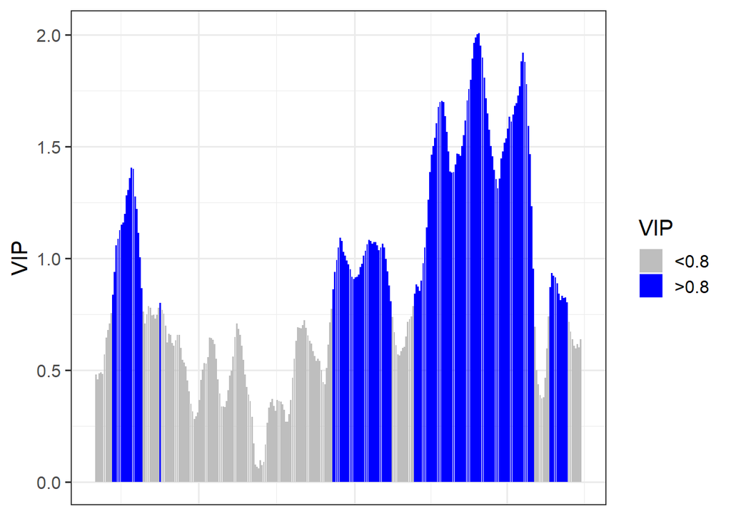

```r
plot_PLS(PLS_results,
         PLS_results_path = "PLS_out")
library(ggplot2)

PLS_gg <- PLS_results$PLS_summary %>%
  mutate(Month = trunc(Date / 100),
         Day = Date - Month * 100,
         Date = NULL)

PLS_gg$Date <- ISOdate(2002,
                       PLS_gg$Month,
                       PLS_gg$Day)
PLS_gg$Date[PLS_gg$JDay <= 0] <-
  ISOdate(2001,
          PLS_gg$Month[PLS_gg$JDay <= 0],
          PLS_gg$Day[PLS_gg$JDay <= 0])

PLS_gg <- PLS_gg %>%
  mutate(VIP_importance = VIP >= 0.8,
         VIP_Coeff = factor(sign(Coef) * VIP_importance))

VIP_plot<- ggplot(PLS_gg,
                  aes(x = Date,
                      y = VIP)) +
  geom_bar(stat='identity',
           aes(fill = VIP_importance))

VIP_plot <- VIP_plot +
  scale_fill_manual(name="VIP",
                    labels = c("<0.8",
                               ">0.8"),
                    values = c("FALSE"="grey",
                               "TRUE"="blue")) +
  theme_bw(base_size=15) +
  theme(axis.text.x = element_blank(),
        axis.ticks.x = element_blank(),
        axis.title.x = element_blank() )

VIP_plot
```

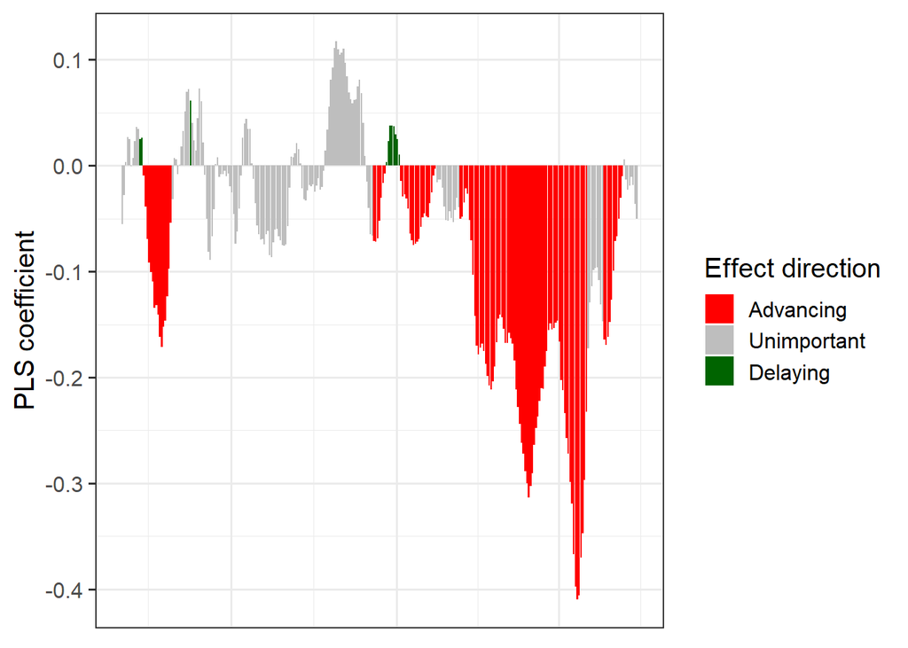

```r
coeff_plot <- ggplot(PLS_gg,
                     aes(x = Date,
                         y = Coef)) +
  geom_bar(stat ='identity',
           aes(fill = VIP_Coeff)) +
  scale_fill_manual(name = "Effect direction",
                    labels = c("Advancing",
                               "Unimportant",
                               "Delaying"),
                    values = c("-1" = "red",
                               "0" = "grey",
                               "1" = "dark green")) +
  theme_bw(base_size = 15) +
  ylab("PLS coefficient") +
  theme(axis.text.x = element_blank(),
        axis.ticks.x = element_blank(),
        axis.title.x = element_blank() )

coeff_plot
```

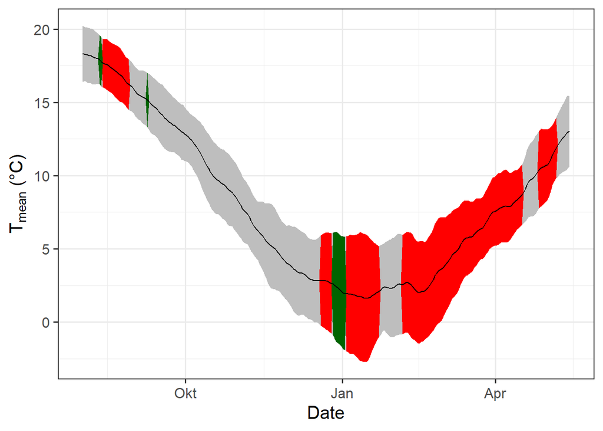

```r
temp_plot <- ggplot(PLS_gg) +
  geom_ribbon(aes(x = Date,
                  ymin = Tmean - Tstdev,
                  ymax = Tmean + Tstdev),
              fill = "grey") +
  geom_ribbon(aes(x = Date,
                  ymin = Tmean - Tstdev * (VIP_Coeff == -1),
                  ymax = Tmean + Tstdev * (VIP_Coeff == -1)),
              fill = "red") +
  geom_ribbon(aes(x = Date,
                  ymin = Tmean - Tstdev * (VIP_Coeff == 1),
                  ymax = Tmean + Tstdev * (VIP_Coeff == 1)),
              fill = "dark green") +
  geom_line(aes(x = Date,
                y = Tmean)) +
  theme_bw(base_size = 15) +
  ylab(expression(paste(T[mean]," (°C)")))

temp_plot
```

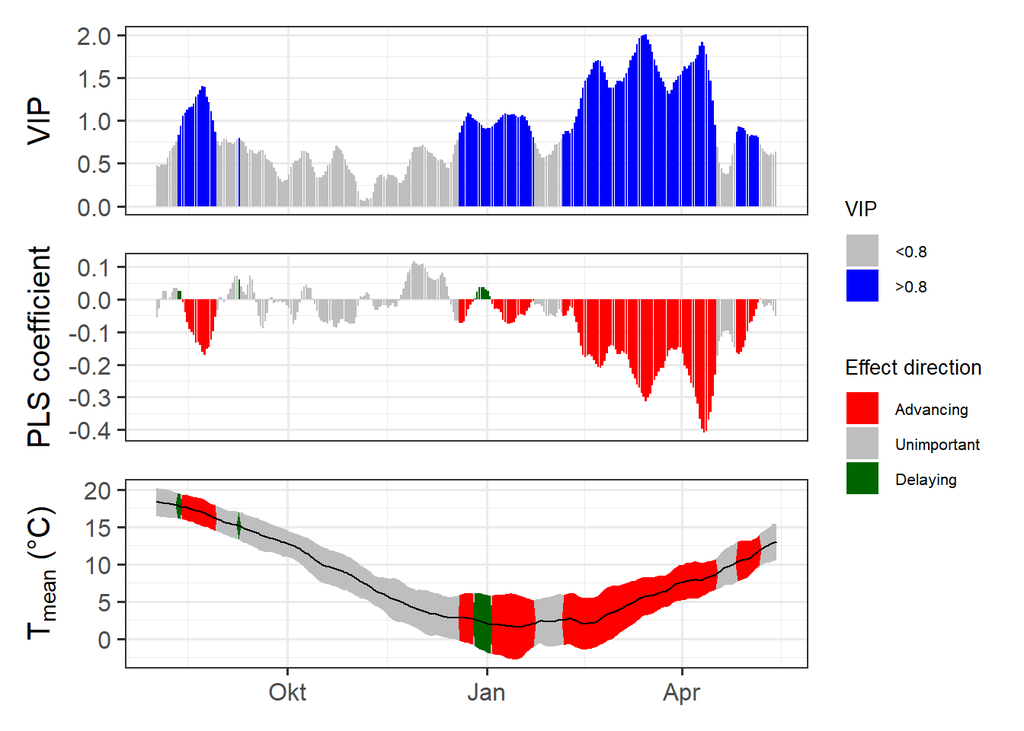

```r
library(patchwork)

plot<- (VIP_plot +
          coeff_plot +
          temp_plot +
          plot_layout(ncol = 1,
            guides = "collect")
        ) & theme(legend.position = "right",
                  legend.text = element_text(size = 8),
                  legend.title = element_text(size = 10),
                  axis.title.x = element_blank())

plot
```

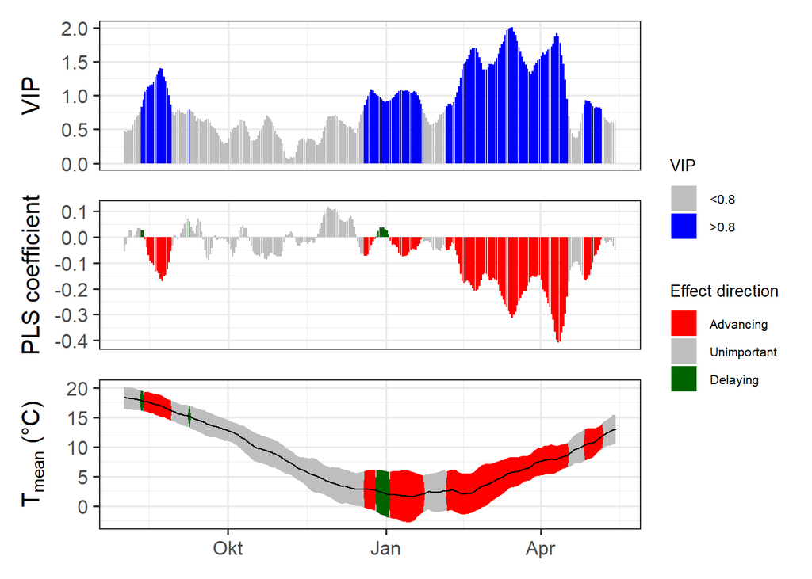

```r
ggplot_PLS <- function(PLS_results)
{
  library(ggplot2)
  PLS_gg <- PLS_results$PLS_summary %>%
    mutate(Month = trunc(Date / 100),
           Day = Date - Month * 100,
           Date = NULL)

  PLS_gg$Date <- ISOdate(2002,
                         PLS_gg$Month,
                         PLS_gg$Day)

  PLS_gg$Date[PLS_gg$JDay <= 0] <-
    ISOdate(2001,
            PLS_gg$Month[PLS_gg$JDay <= 0],
            PLS_gg$Day[PLS_gg$JDay <= 0])

  PLS_gg <- PLS_gg %>%
    mutate(VIP_importance = VIP >= 0.8,
           VIP_Coeff = factor(sign(Coef) * VIP_importance))

  VIP_plot<- ggplot(PLS_gg,aes(x=Date,y=VIP)) +
    geom_bar(stat='identity',aes(fill=VIP>0.8))

  VIP_plot <- VIP_plot +
    scale_fill_manual(name="VIP",
                      labels = c("<0.8", ">0.8"),
                      values = c("FALSE"="grey", "TRUE"="blue")) +
    theme_bw(base_size=15) +
    theme(axis.text.x = element_blank(),
          axis.ticks.x = element_blank(),
          axis.title.x = element_blank())

  coeff_plot <- ggplot(PLS_gg,
                       aes(x = Date,
                           y = Coef)) +
    geom_bar(stat ='identity',
             aes(fill = VIP_Coeff)) +
    scale_fill_manual(name = "Effect direction",
                      labels = c("Advancing",
                                 "Unimportant",
                                 "Delaying"),
                      values = c("-1" = "red",
                                 "0" = "grey",
                                 "1" = "dark green")) +
    theme_bw(base_size = 15) +
    ylab("PLS coefficient") +
    theme(axis.text.x = element_blank(),
          axis.ticks.x = element_blank(),
          axis.title.x = element_blank())

  temp_plot <- ggplot(PLS_gg) +
    geom_ribbon(aes(x = Date,
                    ymin = Tmean - Tstdev,
                    ymax = Tmean + Tstdev),
                fill = "grey") +
    geom_ribbon(aes(x = Date,
                    ymin = Tmean - Tstdev * (VIP_Coeff == -1),
                    ymax = Tmean + Tstdev * (VIP_Coeff == -1)),
                fill = "red") +
    geom_ribbon(aes(x = Date,
                    ymin = Tmean - Tstdev * (VIP_Coeff == 1),
                    ymax = Tmean + Tstdev * (VIP_Coeff == 1)),
                fill = "dark green") +
    geom_line(aes(x = Date,
                  y = Tmean)) +
    theme_bw(base_size = 15) +
    ylab(expression(paste(T[mean]," (°C)")))

  library(patchwork)

  plot<- (VIP_plot +
            coeff_plot +
            temp_plot +
            plot_layout(ncol=1,
                        guides = "collect")
          ) & theme(legend.position = "right",
                    legend.text = element_text(size = 8),
                    legend.title = element_text(size = 10),
                    axis.title.x = element_blank())

  plot}

ggplot_PLS(PLS_results)
```

3. Write down your thoughts on why we’re not seeing the temperature response pattern we may have expected. What happened to the chill response?

## 19.2 PLS responded to temperatures indicating greater heat accumulation which shows early bloom however this is absent for chill accumulation because they are not monotonically related.

# 20 Chapter 22: Successes and limitations of PLS regression analysis

## 20.1 *Exercises on chill model comparison*

1. Briefly explain in what climatic settings we can expect PLS regression to detect the chilling phase - and in what settings this probably won’t work.

In locations such as Davis in California, warm temperatures in winter reduces chill accumulation. While in other locations such as Klein-Altendorf and Beijing, when relatively cold, warming may increase the chill.When temperatures are relatively high, chill accumulation would be reduced by warming. At these two locations, there is no monotonic relationship between temperature and chill accumulation. Therefore, PLS would not produce clear results.

2. How could we overcome this problem?

PLS regression failed to pick up the chilling period in relatively cold locations is that there is no monotonic relationship between temperature and chill effectiveness.

To overcome this problem, we need to convert temperature into something that is monotonically related to chill accumulation. Maybe we can make use of the chill models we already learned about

# 21 Chapter 23: PLS regression with agroclimatic metrics

## 21.1 *Exercises on Chill model comparison*

1. Repeat the PLS_chill_force procedure for the ‘Roter Boskoop’ dataset. Include plots of daily chill and heat accumulation.

```r
library(chillR)
library(magrittr)

temps_hourly <- read_tab("C:/Users/Home/Documents/R Files/Trial Bookdown/data_New_York/TMaxTMin1958-2019_patched.csv") %>%
  stack_hourly_temps(latitude = 43.1)


head(temps_hourly$hourtemps)
```

```
##            DATE YEARMODA Year Month Day Tmin Tmax Tmin_source Tmax_source
## 1      01-01-58 19580101 1958     1   1    5  7.5        <NA>        <NA>
## 22452  01-01-58 19580101 1958     1   1    5  7.5        <NA>        <NA>
## 44903  01-01-58 19580101 1958     1   1    5  7.5        <NA>        <NA>
## 67354  01-01-58 19580101 1958     1   1    5  7.5        <NA>        <NA>
## 89805  01-01-58 19580101 1958     1   1    5  7.5        <NA>        <NA>
## 112256 01-01-58 19580101 1958     1   1    5  7.5        <NA>        <NA>
##        no_Tmin no_Tmax JDay Hour Temp
## 1        FALSE   FALSE    1    0    5
## 22452    FALSE   FALSE    1    1    5
## 44903    FALSE   FALSE    1    2    5
## 67354    FALSE   FALSE    1    3    5
## 89805    FALSE   FALSE    1    4    5
## 112256   FALSE   FALSE    1    5    5
```

```r
daychill <- daily_chill(hourtemps = temps_hourly,
                        running_mean = 1,
                        models = list(
                          Chilling_Hours = Chilling_Hours,
                          Utah_Chill_Units = Utah_Model,
                          Chill_Portions = Dynamic_Model,
                          GDH = GDH)
                        )

head(daychill$daily_chill)
```

```
##     YYMMDD Year Month Day Chilling_Hours Utah_Chill_Units Chill_Portions
## 1 19580101 1958     1   1             19             24.0    0.000000000
## 2 19580102 1958     1   2             16             16.5    1.125678495
## 3 19580103 1958     1   3              5              0.0    0.003207597
## 4 19580104 1958     1   4              9              2.0    0.208134160
## 5 19580105 1958     1   5             24             24.0    1.266485806
## 6 19580106 1958     1   6             24             21.5    0.738858345
##          GDH     Tmean no_Tmin no_Tmax
## 1 10.5101397  5.474222   FALSE   FALSE
## 2 13.7707171  3.596476   FALSE   FALSE
## 3  0.0000000 -2.518361   FALSE   FALSE
## 4  0.0000000 -1.683636   FALSE   FALSE
## 5  0.0000000  3.012222   FALSE    TRUE
## 6  0.4997425  3.352441   FALSE   FALSE
```

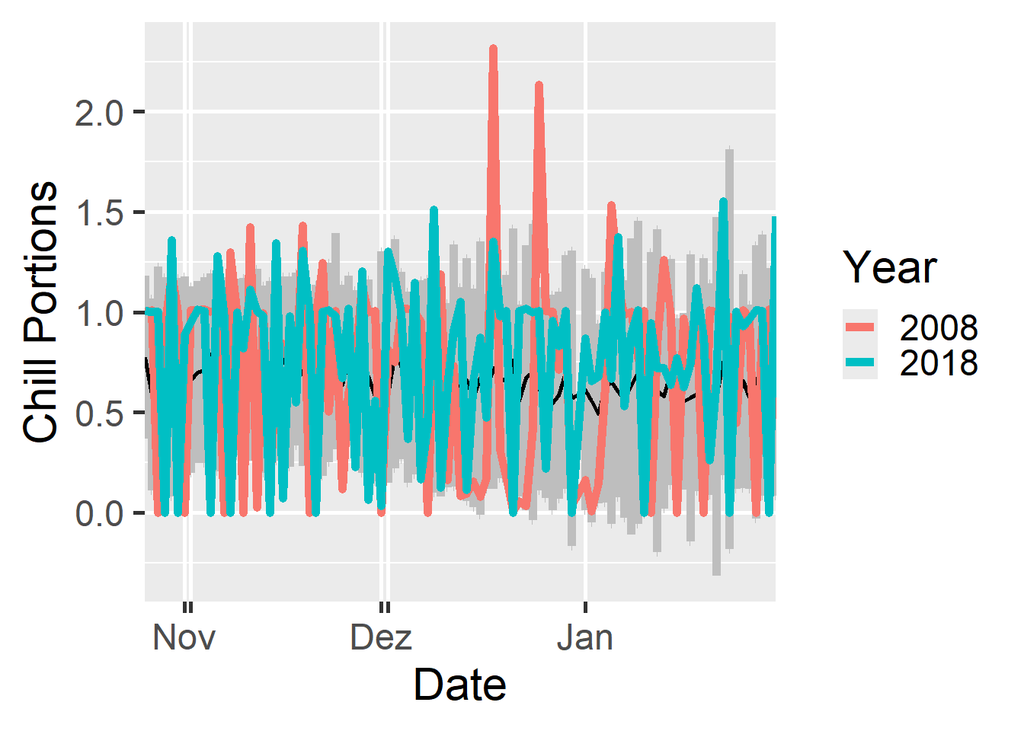

```r
dc <- make_daily_chill_plot2(daychill,
                             metrics = c("Chill_Portions"),
                             cumulative = FALSE,
                             startdate = 300,
                             enddate = 30,
                             focusyears = c(2008,2018),
                             metriclabels = "Chill Portions")
```

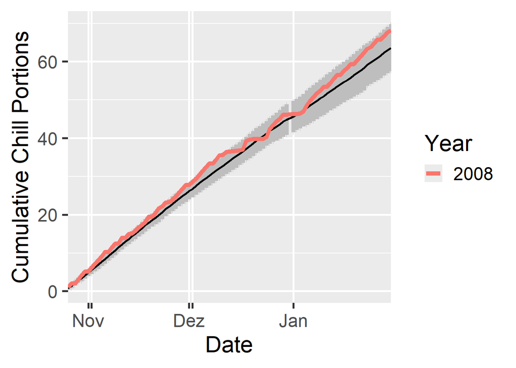

```r
dc <- make_daily_chill_plot2(daychill,
                             metrics = c("Chill_Portions"),
                             cumulative = TRUE,
                             startdate = 300,
                             enddate = 30,
                             focusyears = c(2008),
                             metriclabels = "Chill Portions")
```

```r
library(dplyr)

Roter_Boskoop <- read_tab("C:/Users/Home/Documents/R Files/Trial Bookdown/data_New_York/Roter_Boskoop_bloom_1958_2019.csv.csv") %>%
  select(Pheno_year, First_bloom) %>%
  mutate(Year = as.numeric(substr(First_bloom, 1, 4)),
         Month = as.numeric(substr(First_bloom, 5, 6)),
         Day = as.numeric(substr(First_bloom, 7, 8))) %>%
  make_JDay() %>%
  select(Pheno_year,
         JDay) %>%
  rename(Year = Pheno_year,
         pheno = JDay)


plscf <- PLS_chill_force(daily_chill_obj = daychill,
                         bio_data_frame = Roter_Boskoop,
                         split_month = 6,
                         chill_models = "Chill_Portions",
                         heat_models = "GDH")

head(plscf$Chill_Portions$GDH$PLS_summary)
```

```
##   Date  Type JDay        Coef       VIP MetricMean MetricStdev
## 1  701 Chill -183  0.14696728 1.2458136 0.08337297   0.2788507
## 2  702 Chill -182 -0.01406667 0.2856791 0.05012075   0.2203154
## 3  703 Chill -181  0.00945019 0.5483639 0.06722064   0.2536409
## 4  704 Chill -180 -0.10797135 0.5973938 0.06712402   0.2532811
## 5  705 Chill -179  0.22044678 1.9679578 0.06603972   0.2492901
## 6  706 Chill -178 -0.02465086 0.1964161 0.01679378   0.1300841
```

2. Run PLS_chill_force analyses for all three major chill models. Delineate your best estimates of chilling and forcing phases for all of them.

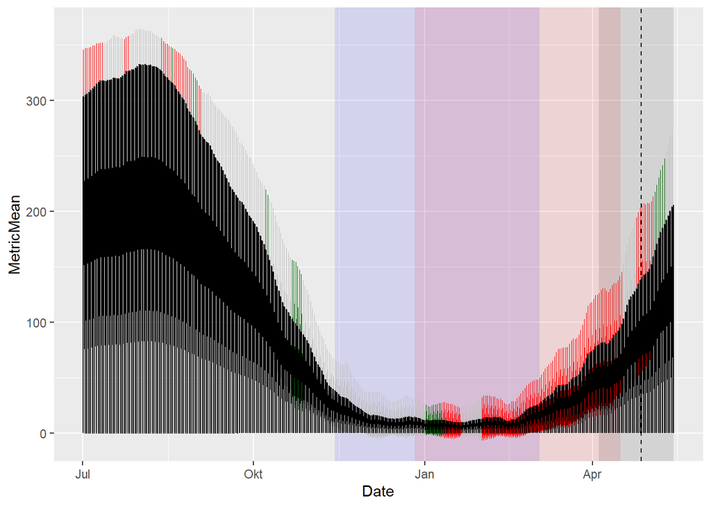

```r
plot_PLS(plscf,
         PLS_results_path = "data_New_York/plscf_outputs_NY")

plscf <- PLS_chill_force(daily_chill_obj = daychill,
                         bio_data_frame = Roter_Boskoop,
                         split_month = 6,
                         chill_models = "Chill_Portions",
                         heat_models = "GDH",
                         runn_means = 11)




plot_PLS(plscf,
         PLS_results_path = "data_New_York/plscf_outputs_NY_11days")



plot_PLS(plscf,
         PLS_results_path = "data_New_York/plscf_outputs_NY_11days_periods",
         add_chill = c(-48,62),
         add_heat = c(-5,105.5))

PLS_gg <- plscf$Chill_Portions$GDH$PLS_summary %>%
  mutate(Month = trunc(Date/100),
         Day = Date - Month * 100,
         Date = ISOdate(2002,
                        Month,
                        Day))

PLS_gg[PLS_gg$JDay <= 0,"Date"]<-
  ISOdate(2001,
          PLS_gg$Month[PLS_gg$JDay <= 0],
          PLS_gg$Day[PLS_gg$JDay <= 0])

PLS_gg <- PLS_gg %>%
  mutate(VIP_importance = VIP >= 0.8,
         VIP_Coeff = factor(sign(Coef) * VIP_importance))

chill_start_JDay <- -48
chill_end_JDay <- 62
heat_start_JDay <- -5
heat_end_JDay <- 105.5

chill_start_date <- ISOdate(2001,
                            12,
                            31) + chill_start_JDay * 24 * 3600
chill_end_date <- ISOdate(2001,
                          12,
                          31) + chill_end_JDay * 24 * 3600
heat_start_date <- ISOdate(2001,
                           12,
                           31) + heat_start_JDay * 24 * 3600
heat_end_date <- ISOdate(2001,
                         12,
                         31) + heat_end_JDay * 24 * 3600

library(ggplot2)

temp_plot <- ggplot(PLS_gg,
                    x = Date) +
  annotate("rect",
           xmin = chill_start_date,
           xmax = chill_end_date,
           ymin = -Inf,
           ymax = Inf,
           alpha = .1,
           fill = "blue") +
  annotate("rect",
           xmin = heat_start_date,
           xmax = heat_end_date,
           ymin = -Inf,
           ymax = Inf,
           alpha = .1,
           fill = "red") +
  annotate("rect",
           xmin = ISOdate(2001,
                          12,
                          31) +
             min(plscf$pheno$pheno,
                 na.rm = TRUE) * 24 * 3600,
           xmax = ISOdate(2001,
                          12,
                          31) +
             max(plscf$pheno$pheno,
                 na.rm = TRUE) * 24 * 3600,
           ymin = -Inf,
           ymax = Inf,
           alpha = .1,
           fill = "black") +
  geom_vline(xintercept = ISOdate(2001,
                                  12,
                                  31) +
               median(plscf$pheno$pheno,
                      na.rm = TRUE) * 24 * 3600,
             linetype = "dashed") +
  geom_ribbon(aes(x = Date,
                  ymin = MetricMean - MetricStdev ,
                  ymax = MetricMean + MetricStdev),
              fill="grey") +
  geom_ribbon(aes(x = Date,
                  ymin = MetricMean - MetricStdev * (VIP_Coeff == -1),
                  ymax = MetricMean + MetricStdev * (VIP_Coeff == -1)),
              fill = "red") +
  geom_ribbon(aes(x = Date,
                  ymin = MetricMean - MetricStdev * (VIP_Coeff == 1),
                  ymax = MetricMean + MetricStdev * (VIP_Coeff == 1)),
              fill = "dark green") +
  geom_line(aes(x = Date,
                y = MetricMean ))

temp_plot
```

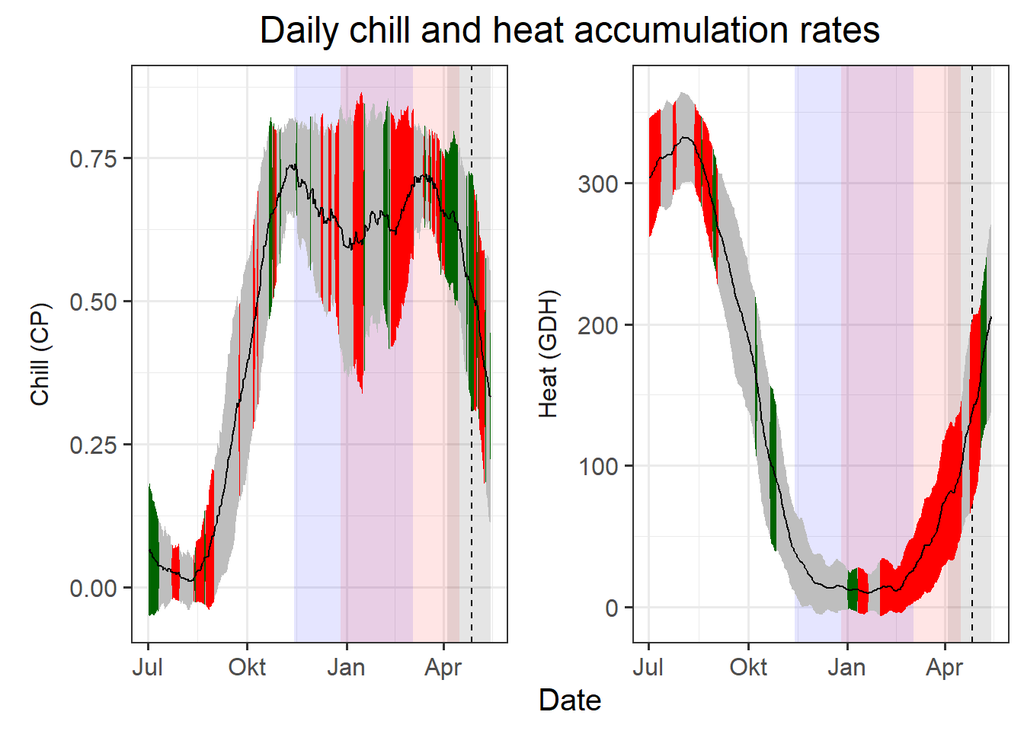

```r
temp_plot <- temp_plot +
  facet_wrap(vars(Type),
             scales = "free_y",
             strip.position = "left",
             labeller =
               labeller(Type = as_labeller(
               c(Chill = "Chill (CP)",
                 Heat = "Heat (GDH)")))) +
  ggtitle("Daily chill and heat accumulation rates") +
  theme_bw(base_size = 15) +
  theme(strip.background = element_blank(),
        strip.placement = "outside",
        strip.text.y = element_text(size =12),
        plot.title = element_text(hjust = 0.5),
        axis.title.y = element_blank()
        )

temp_plot
```

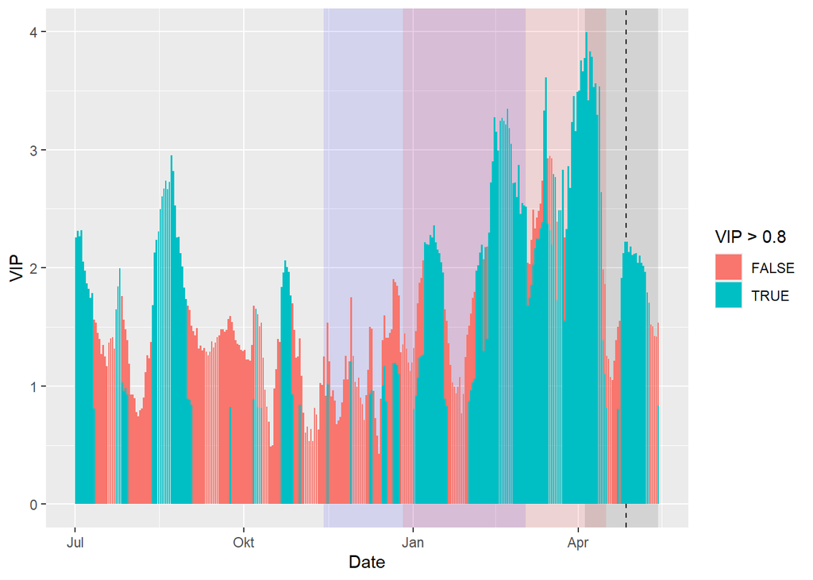

```r
VIP_plot<- ggplot(PLS_gg,
                  aes(x = Date,
                      y = VIP)) +
  annotate("rect",
           xmin = chill_start_date,
           xmax = chill_end_date,
           ymin = -Inf,
           ymax = Inf,
           alpha = .1,
           fill = "blue") +
  annotate("rect",
           xmin = heat_start_date,
           xmax = heat_end_date,
           ymin = -Inf,
           ymax = Inf,
           alpha = .1,
           fill = "red") +
  annotate("rect",
           xmin = ISOdate(2001,
                          12,
                          31) +
             min(plscf$pheno$pheno,
                 na.rm = TRUE) * 24 * 3600,
           xmax = ISOdate(2001,
                          12,
                          31) +
             max(plscf$pheno$pheno,
                 na.rm = TRUE) * 24 * 3600,
           ymin = -Inf,
           ymax = Inf,
           alpha = .1,
           fill = "black") +
  geom_vline(xintercept = ISOdate(2001,
                                  12,
                                  31) +
               median(plscf$pheno$pheno,
                      na.rm = TRUE) * 24 * 3600,
             linetype = "dashed") +
  geom_bar(stat = 'identity',
           aes(fill = VIP > 0.8))

VIP_plot
```

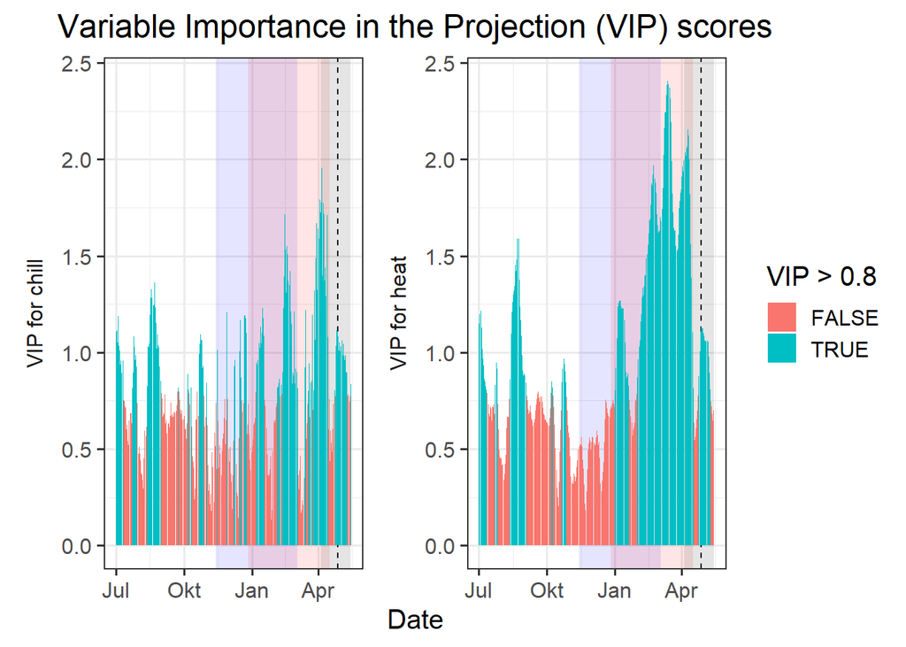

```r
VIP_plot <- VIP_plot +
  facet_wrap(vars(Type),
             scales = "free",
             strip.position = "left",
             labeller =
               labeller(Type = as_labeller(
                 c(Chill = "VIP for chill",
                   Heat = "VIP for heat")))) +
  scale_y_continuous(
    limits = c(0,
               max(plscf$Chill_Portions$GDH$PLS_summary$VIP))) +
  ggtitle("Variable Importance in the Projection (VIP) scores") +
  theme_bw(base_size = 15) +
  theme(strip.background = element_blank(),
        strip.placement = "outside",
        strip.text.y = element_text(size = 12),
        plot.title = element_text(hjust = 0.5),
        axis.title.y = element_blank()
        )

VIP_plot
```

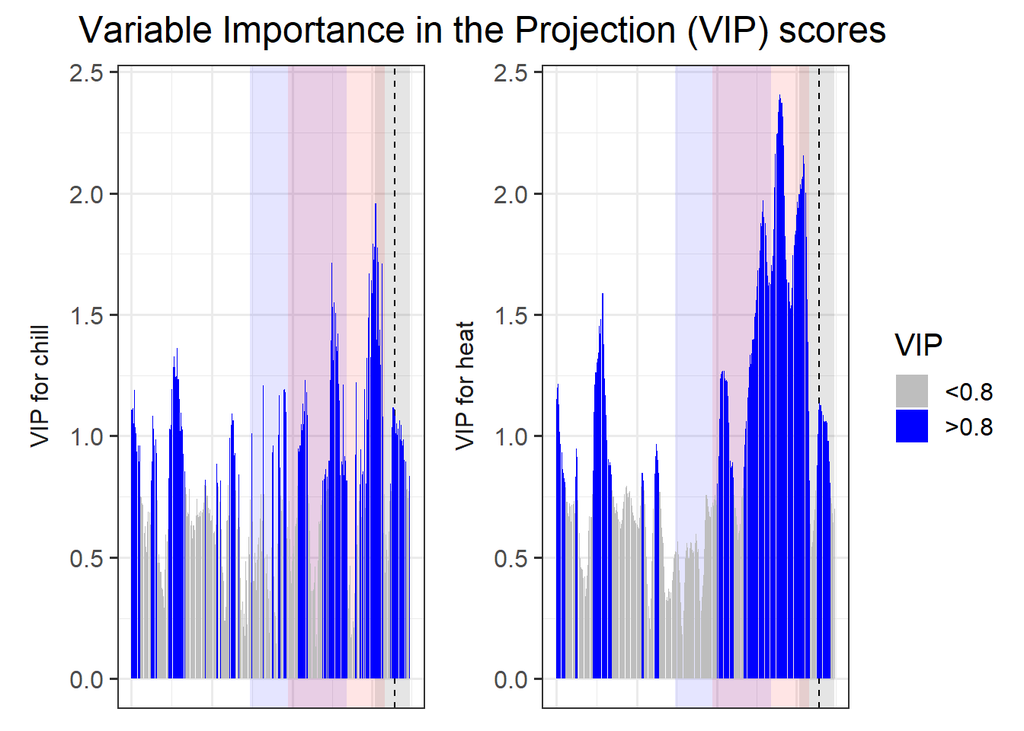

```r
VIP_plot <- VIP_plot +
  scale_fill_manual(name = "VIP",
                    labels = c("<0.8", ">0.8"),
                    values = c("FALSE" = "grey",
                               "TRUE" = "blue")) +
  theme(axis.text.x = element_blank(),
        axis.ticks.x = element_blank(),
        axis.title.x = element_blank(),
        axis.title.y = element_blank())

VIP_plot
```

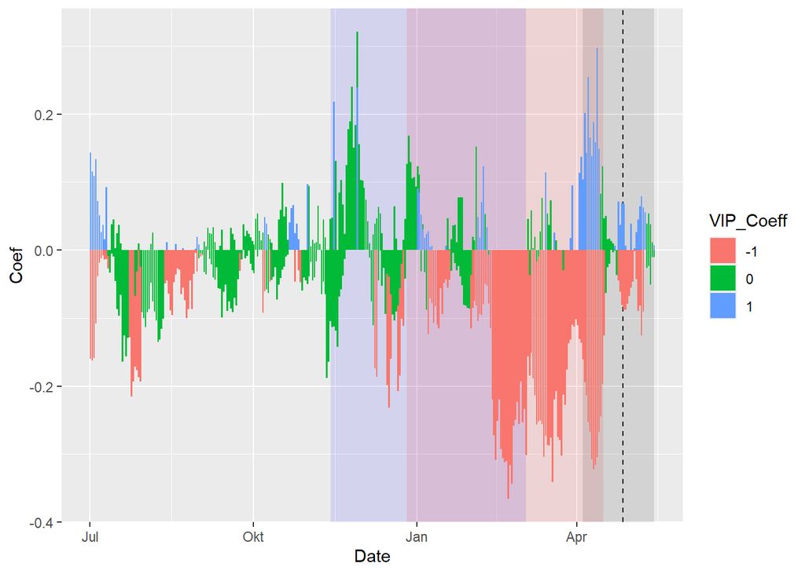

```r
coeff_plot <- ggplot(PLS_gg,
                     aes(x = Date,
                         y = Coef)) +
  annotate("rect",
           xmin = chill_start_date,
           xmax = chill_end_date,
           ymin = -Inf,
           ymax = Inf,
           alpha = .1,
           fill = "blue") +
  annotate("rect",
           xmin = heat_start_date,
           xmax = heat_end_date,
           ymin = -Inf,
           ymax = Inf,
           alpha = .1,
           fill = "red") +
  annotate("rect",
           xmin = ISOdate(2001,
                          12,
                          31) +
             min(plscf$pheno$pheno,
                 na.rm=TRUE) * 24 * 3600,
           xmax = ISOdate(2001,
                          12,
                          31) +
             max(plscf$pheno$pheno,
                 na.rm = TRUE) * 24 * 3600,
           ymin = -Inf,
           ymax = Inf,
           alpha = .1,
           fill = "black") +
  geom_vline(xintercept = ISOdate(2001,
                                  12,
                                  31) +
               median(plscf$pheno$pheno,
                      na.rm = TRUE) * 24 * 3600,
             linetype = "dashed") +
  geom_bar(stat = 'identity',
           aes(fill = VIP_Coeff))

coeff_plot
```

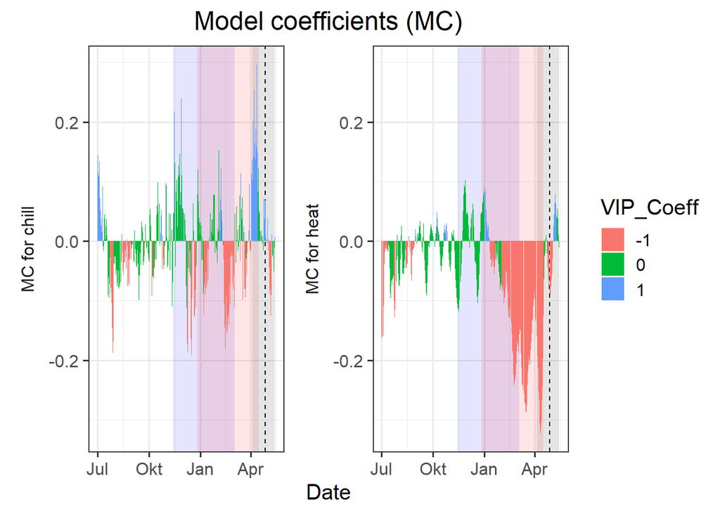

```r
coeff_plot <- coeff_plot +
  facet_wrap(vars(Type),
             scales = "free",
             strip.position = "left",
             labeller =
               labeller(
                 Type = as_labeller(
                   c(Chill = "MC for chill",
                     Heat = "MC for heat")))) +
  scale_y_continuous(
    limits = c(min(plscf$Chill_Portions$GDH$PLS_summary$Coef),
               max(plscf$Chill_Portions$GDH$PLS_summary$Coef))) +
  ggtitle("Model coefficients (MC)") +
  theme_bw(base_size = 15) +
  theme(strip.background = element_blank(),
        strip.placement = "outside",
        strip.text.y = element_text(size = 12),
        plot.title = element_text(hjust = 0.5),
        axis.title.y = element_blank()
        )

coeff_plot
```

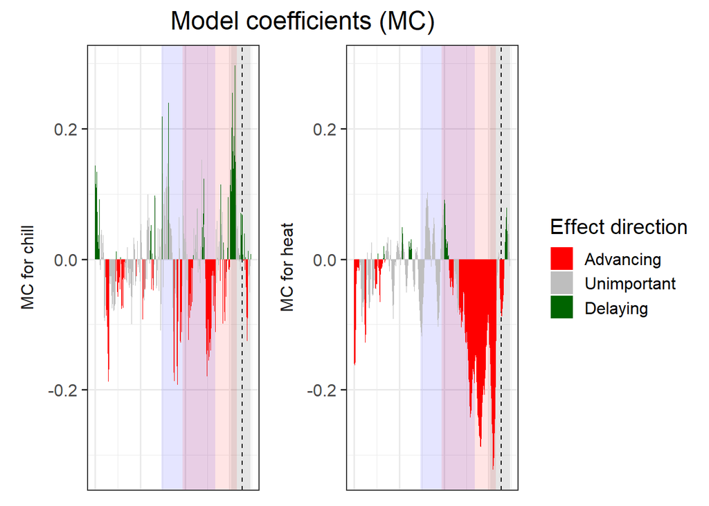

```r
coeff_plot <- coeff_plot +
  scale_fill_manual(name="Effect direction",
                    labels = c("Advancing",
                               "Unimportant",
                               "Delaying"),
                    values = c("-1" = "red",
                               "0" = "grey",
                               "1" = "dark green")) +
  ylab("PLS coefficient") +
  theme(axis.text.x = element_blank(),
        axis.ticks.x = element_blank(),
        axis.title.x = element_blank(),
        axis.title.y = element_blank())

coeff_plot
```

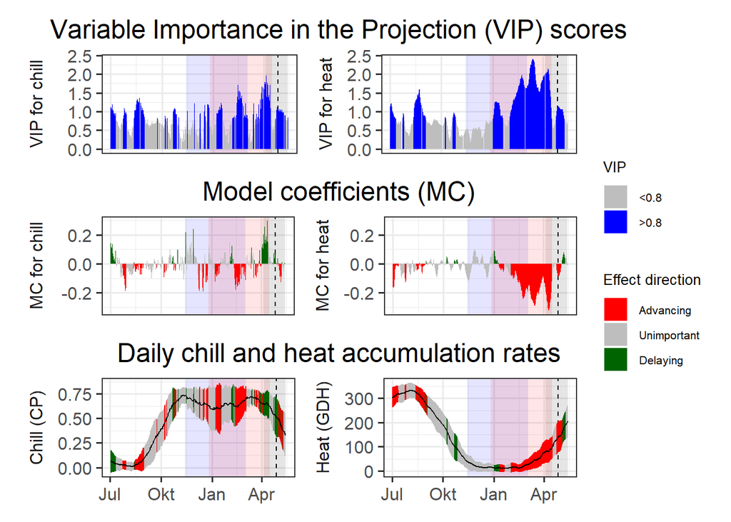

```r
library(patchwork)

plot<- (VIP_plot +
          coeff_plot +
          temp_plot +
          plot_layout(ncol = 1,
            guides = "collect")
        ) & theme(legend.position = "right",
                  legend.text = element_text(size = 8),
                  legend.title = element_text(size = 10),
                  axis.title.x = element_blank())

plot
```

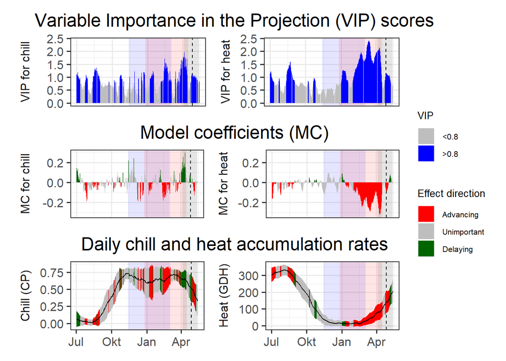

```r
plot_PLS_chill_force <- function(plscf,
                                 chill_metric = "Chill_Portions",
                                 heat_metric = "GDH",
                                 chill_label = "CP",
                                 heat_label = "GDH",
                                 chill_phase = c(-48, 62),
                                 heat_phase = c(-5, 105.5))
{
  PLS_gg <- plscf[[chill_metric]][[heat_metric]]$PLS_summary %>%
    mutate(Month = trunc(Date/100),
           Day = Date - Month * 100,
           Date = ISOdate(2002,
                          Month,
                          Day))

  PLS_gg[PLS_gg$JDay <= 0,"Date"]<-
    ISOdate(2001,
            PLS_gg$Month[PLS_gg$JDay <= 0],
            PLS_gg$Day[PLS_gg$JDay <= 0])

  PLS_gg <- PLS_gg %>%
    mutate(VIP_importance = VIP >= 0.8,
           VIP_Coeff = factor(sign(Coef) * VIP_importance))

  chill_start_date <- ISOdate(2001,
                              12,
                              31) + chill_phase[1] * 24 * 3600
  chill_end_date <- ISOdate(2001,
                            12,
                            31) + chill_phase[2] * 24 * 3600
  heat_start_date <- ISOdate(2001,
                             12,
                             31) + heat_phase[1] * 24 * 3600
  heat_end_date <- ISOdate(2001,
                           12,
                           31) + heat_phase[2] * 24 * 3600




  temp_plot <- ggplot(PLS_gg) +
    annotate("rect",
             xmin = chill_start_date,
             xmax = chill_end_date,
             ymin = -Inf,
             ymax = Inf,
             alpha = .1,
             fill = "blue") +
    annotate("rect",
             xmin = heat_start_date,
             xmax = heat_end_date,
             ymin = -Inf,
             ymax = Inf,
             alpha = .1,
             fill = "red") +
    annotate("rect",
             xmin = ISOdate(2001,
                            12,
                            31) +
               min(plscf$pheno$pheno,
                   na.rm = TRUE) * 24 * 3600,
             xmax = ISOdate(2001,
                            12,
                            31) +
               max(plscf$pheno$pheno,
                   na.rm = TRUE) * 24 * 3600,
             ymin = -Inf,
             ymax = Inf,
             alpha = .1,
             fill = "black") +
    geom_vline(xintercept = ISOdate(2001,
                                    12,
                                    31) +
                 median(plscf$pheno$pheno,
                        na.rm=TRUE) * 24 * 3600,
               linetype = "dashed") +
    geom_ribbon(aes(x = Date,
                    ymin = MetricMean - MetricStdev ,
                    ymax = MetricMean + MetricStdev ),
                fill = "grey") +
    geom_ribbon(aes(x = Date,
                    ymin = MetricMean - MetricStdev * (VIP_Coeff == -1),
                    ymax = MetricMean + MetricStdev * (VIP_Coeff == -1)),
                fill = "red") +
    geom_ribbon(aes(x = Date,
                    ymin = MetricMean - MetricStdev * (VIP_Coeff == 1),
                    ymax = MetricMean + MetricStdev * (VIP_Coeff == 1)),
                fill = "dark green") +
    geom_line(aes(x = Date,
                  y = MetricMean)) +
    facet_wrap(vars(Type),
               scales = "free_y",
               strip.position = "left",
               labeller =
                 labeller(
                   Type =
                     as_labeller(c(Chill = paste0("Chill (",
                                                  chill_label,
                                                  ")"),
                                   Heat = paste0("Heat (",
                                                 heat_label,
                                                 ")"))))) +
    ggtitle("Daily chill and heat accumulation rates") +
    theme_bw(base_size = 15) +
    theme(strip.background = element_blank(),
          strip.placement = "outside",
          strip.text.y = element_text(size = 12),
          plot.title = element_text(hjust = 0.5),
          axis.title.y = element_blank()
          )

  VIP_plot <- ggplot(PLS_gg,
                     aes(x = Date,
                         y = VIP)) +
    annotate("rect",
             xmin = chill_start_date,
             xmax = chill_end_date,
             ymin = -Inf,
             ymax = Inf,
             alpha = .1,
             fill = "blue") +
    annotate("rect",
             xmin = heat_start_date,
             xmax = heat_end_date,
             ymin = -Inf,
             ymax = Inf,
             alpha = .1,
             fill = "red") +
    annotate("rect",
             xmin = ISOdate(2001,
                            12,
                            31) + min(plscf$pheno$pheno,
                                      na.rm = TRUE) * 24 * 3600,
             xmax = ISOdate(2001,
                            12,
                            31) + max(plscf$pheno$pheno,
                                      na.rm = TRUE) * 24 * 3600,
             ymin = -Inf,
             ymax = Inf,
             alpha = .1,
             fill = "black") +
    geom_vline(xintercept = ISOdate(2001,
                                    12,
                                    31) + median(plscf$pheno$pheno,
                                                 na.rm = TRUE) * 24 * 3600,
               linetype = "dashed") +
    geom_bar(stat = 'identity',
             aes(fill = VIP>0.8)) +
    facet_wrap(vars(Type),
               scales = "free",
               strip.position = "left",
               labeller =
                 labeller(
                   Type = as_labeller(c(Chill="VIP for chill",
                                        Heat="VIP for heat")))) +
    scale_y_continuous(
      limits=c(0,
               max(plscf[[chill_metric]][[heat_metric]]$PLS_summary$VIP))) +
    ggtitle("Variable Importance in the Projection (VIP) scores") +
    theme_bw(base_size = 15) +
    theme(strip.background = element_blank(),
          strip.placement = "outside",
          strip.text.y = element_text(size = 12),
          plot.title = element_text(hjust = 0.5),
          axis.title.y = element_blank()
          ) +
    scale_fill_manual(name = "VIP",
                      labels = c("<0.8", ">0.8"),
                      values = c("FALSE" = "grey",
                                 "TRUE" = "blue")) +
    theme(axis.text.x = element_blank(),
          axis.ticks.x = element_blank(),
          axis.title.x = element_blank(),
          axis.title.y = element_blank())

  coeff_plot <- ggplot(PLS_gg,
                       aes(x = Date,
                           y = Coef)) +
    annotate("rect",
             xmin = chill_start_date,
             xmax = chill_end_date,
             ymin = -Inf,
             ymax = Inf,
             alpha = .1,
             fill = "blue") +
    annotate("rect",
             xmin = heat_start_date,
             xmax = heat_end_date,
             ymin = -Inf,
             ymax = Inf,
             alpha = .1,
             fill = "red") +
    annotate("rect",
             xmin = ISOdate(2001,
                            12,
                            31) + min(plscf$pheno$pheno,
                                      na.rm = TRUE) * 24 * 3600,
             xmax = ISOdate(2001,
                            12,
                            31) + max(plscf$pheno$pheno,
                                      na.rm = TRUE) * 24 * 3600,
             ymin = -Inf,
             ymax = Inf,
             alpha = .1,
             fill = "black") +
    geom_vline(xintercept = ISOdate(2001,
                                    12,
                                    31) + median(plscf$pheno$pheno,
                                                 na.rm = TRUE) * 24 * 3600,
               linetype = "dashed") +
    geom_bar(stat = 'identity',
             aes(fill = VIP_Coeff)) +
    facet_wrap(vars(Type),
               scales = "free",
               strip.position = "left",
               labeller =
                 labeller(
                   Type = as_labeller(c(Chill = "MC for chill",
                                        Heat = "MC for heat")))) +
    scale_y_continuous(
      limits = c(min(plscf[[chill_metric]][[heat_metric]]$PLS_summary$Coef),
                 max(plscf[[chill_metric]][[heat_metric]]$PLS_summary$Coef))) +
    ggtitle("Model coefficients (MC)") +
    theme_bw(base_size = 15) +
    theme(strip.background = element_blank(),
          strip.placement = "outside",
          strip.text.y = element_text(size = 12),
          plot.title = element_text(hjust = 0.5),
          axis.title.y = element_blank()
          ) +
    scale_fill_manual(name="Effect direction",
                      labels = c("Advancing",
                                 "Unimportant",
                                 "Delaying"),
                      values = c("-1" = "red",
                                 "0" = "grey",
                                 "1" = "dark green")) +
    ylab("PLS coefficient") +
    theme(axis.text.x = element_blank(),
          axis.ticks.x = element_blank(),
          axis.title.x = element_blank(),
          axis.title.y = element_blank())
   library(patchwork)

  plot <- (VIP_plot +
             coeff_plot +
             temp_plot +
             plot_layout(ncol=1,
                         guides = "collect")
           ) & theme(legend.position = "right",
                     legend.text = element_text(size = 8),
                     legend.title = element_text(size = 10),
                     axis.title.x = element_blank())

plot

}

plot_PLS_chill_force(plscf)
```

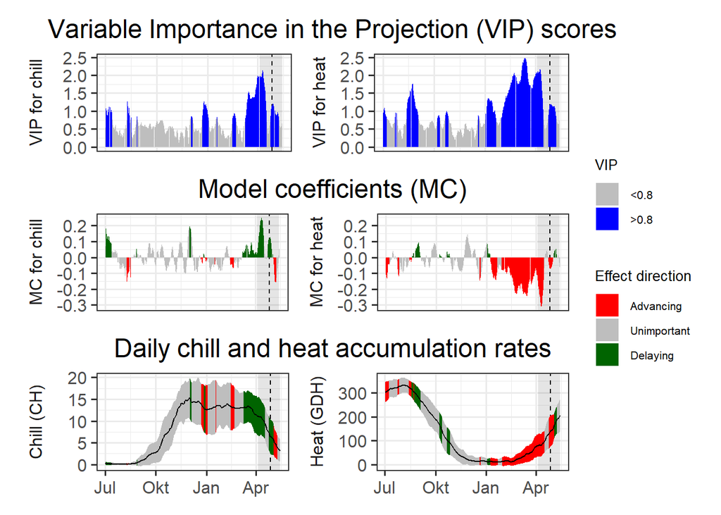

```r
daychill <- daily_chill(hourtemps = temps_hourly,
                        running_mean = 11,
                        models = list(Chilling_Hours = Chilling_Hours,
                                      Utah_Chill_Units = Utah_Model,
                                      Chill_Portions = Dynamic_Model,
                                      GDH = GDH)
                        )

plscf <- PLS_chill_force(daily_chill_obj = daychill,
                         bio_data_frame = Roter_Boskoop,
                         split_month = 6,
                         chill_models = c("Chilling_Hours",
                                          "Utah_Chill_Units",
                                          "Chill_Portions"),
                       heat_models = c("GDH"))

plot_PLS_chill_force(plscf,
                     chill_metric = "Chilling_Hours",
                     heat_metric = "GDH",
                     chill_label = "CH",
                     heat_label = "GDH",
                     chill_phase = c(0,0),
                     heat_phase = c(0,0))
```

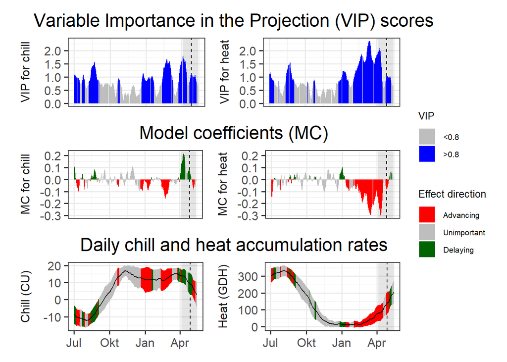

```r
plot_PLS_chill_force(plscf,
                     chill_metric = "Utah_Chill_Units",
                     heat_metric = "GDH",
                     chill_label = "CU",
                     heat_label = "GDH",
                     chill_phase = c(0,0),
                     heat_phase = c(0,0))
```

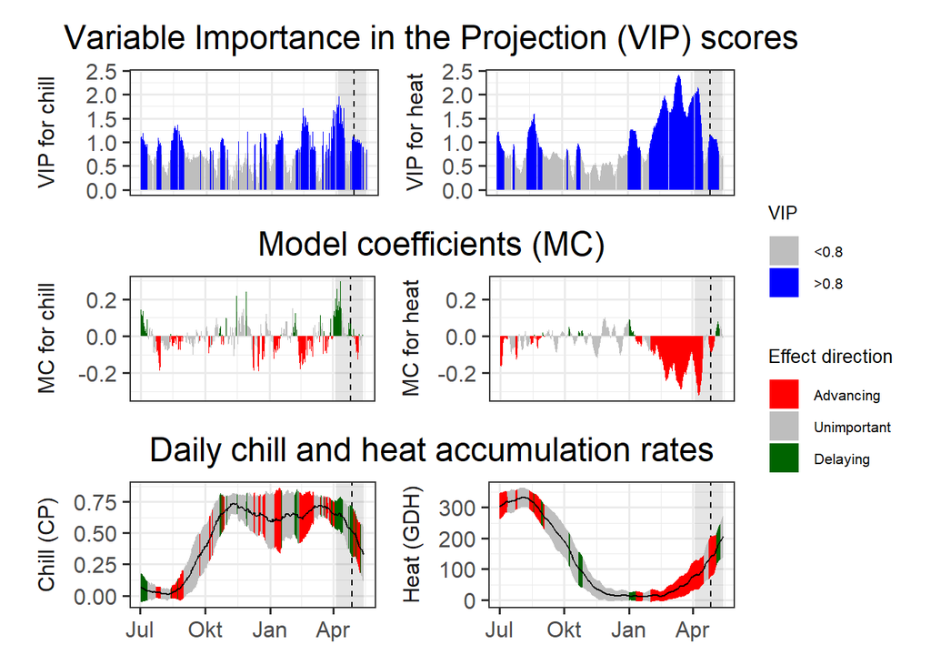

```r
plot_PLS_chill_force(plscf,
                     chill_metric = "Chill_Portions",
                     heat_metric = "GDH",
                     chill_label = "CP",
                     heat_label = "GDH",
                     chill_phase = c(0,0),
                     heat_phase = c(0,0))
```

# 22 Chapter 24: PLS regression with agroclimatic metrics

## 22.1 *Exercises on examples of PLS regression with agroclimatic metrics*

1. Look across all the PLS results presented above. Can you detect a pattern in where chilling and forcing periods could be delineated clearly, and where this attempt failed?

PLS regression doesn’t allow easy delineation of temperature response phases, especially when it comes to the chilling period. This problem didn’t really go away after replacing temperatures with agroclimatic metrics in the analysis.

PLS looks responses of a variable to variation in the input variable. This response should be monotonic (bloom date should be positively or negatively correlated with the input variables). The sign of this relationship should not change halfway through the range of the input variables.

Another prerequisite for a successful PLS regression, is that there needs to be meaningful variation in the signal variables in the first place.

2. Think about possible reasons for the success or failure of PLS analysis based on agroclimatic metrics. Write down your thoughts.

# 23 Chapter 25: PLS regression with agroclimatic metrics

## 23.1 *Exercises on expected PLS responsiveness*

Produce chill and heat model sensitivity plots for the location you focused on in previous exercises.

```r
library(chillR)
library(tidyverse)

mon <- 1 # Month
ndays <- 31 # Number of days per month
tmin <- 1
tmax <- 8
latitude <- 43 #Rochester


weather <- make_all_day_table(
            data.frame(Year = c(2001, 2001),
                       Month = c(mon, mon),
                       Day = c(1, ndays),
                       Tmin = c(0, 0),
                       Tmax = c(0, 0))) %>%
  mutate(Tmin = tmin,
         Tmax = tmax)

hourly_temps <- stack_hourly_temps(weather,
                                   latitude = latitude)

CPs <- Dynamic_Model(
     hourly_temps$hourtemps$Temp)

daily_CPs <- tail(CPs, 1) / nrow(weather)

daily_CPs #chill portions
```

```
## [1] 0.6857511
```

```r
latitude <- 43.1

month_range <- c(10, 11, 12, 1, 2, 3)

Tmins <- c(-20:20) # calculate sensitivity for expected temps in winter
Tmaxs <- c(-15:30) # range

mins <- NA
maxs <- NA
CP <- NA
month <- NA
temp_model <- Dynamic_Model # model for temp


for(mon in month_range)
    {days_month <- as.numeric( # number of days in a month
      difftime( ISOdate(2002, # time difference of 31 days
                        mon+1,
                        1),
                ISOdate(2002,
                        mon,
                        1)))

    if(mon == 12) days_month <- 31

    weather <- make_all_day_table(
                data.frame(Year = c(2001, 2001),
                           Month = c(mon, mon),
                           Day = c(1, days_month),
                           Tmin = c(0, 0),
                           Tmax = c(0, 0)))

    for(tmin in Tmins)
      for(tmax in Tmaxs)
        if(tmax >= tmin)
          {
          hourtemps <- weather %>%
            mutate(Tmin = tmin,
                   Tmax = tmax) %>%
            stack_hourly_temps(latitude = latitude) %>%
            pluck("hourtemps", "Temp")

          CP <- c(CP,
                  tail(do.call(temp_model,
                          list(hourtemps)), 1) /
                    days_month)
          mins <- c(mins, tmin)
          maxs <- c(maxs, tmax)
          month <- c(month, mon)
        }
}

results <- data.frame(Month = month,
                      Tmin = mins,
                      Tmax = maxs,
                      CP)

results <- results[!is.na(results$Month),
                   ]


write.csv(results,
          "C:/Users/Home/Documents/R Files/Trial Bookdown/data_New_York/model_sensitivity_development.csv",
          row.names = FALSE)

head(results)
```

```
##   Month Tmin Tmax                    CP
## 2    10  -20  -15 0.0000000000001085391
## 3    10  -20  -14 0.0000000000006373370
## 4    10  -20  -13 0.0000000000037399058
## 5    10  -20  -12 0.0000000000218431572
## 6    10  -20  -11 0.0000000001266344358
## 7    10  -20  -10 0.0000000007273857353
```

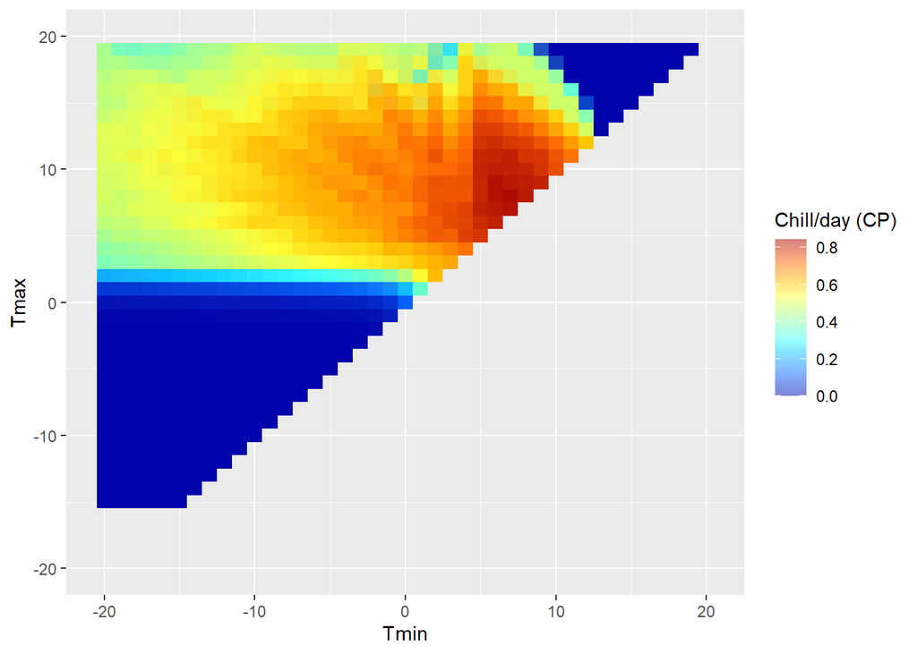

```r
results <- read.csv("C:/Users/Home/Documents/R Files/Trial Bookdown/data_New_York/model_sensitivity_development.csv")



library(ggplot2)
library(colorRamps)

results$Month_names <- factor(results$Month,
                              levels = month_range,# october to march
                              labels = month.name[month_range])

DM_sensitivity <- ggplot(results, # heat map
                         aes(x = Tmin,
                             y = Tmax,
                             fill = CP)) +
  geom_tile() +
  scale_fill_gradientn(colours = alpha(matlab.like(15),
                                       alpha = .5),
                       name = "Chill/day (CP)") +
  ylim(min(results$Tmax),
       max(results$Tmax)) +
  ylim(min(results$Tmin),
       max(results$Tmin))
DM_sensitivity
```

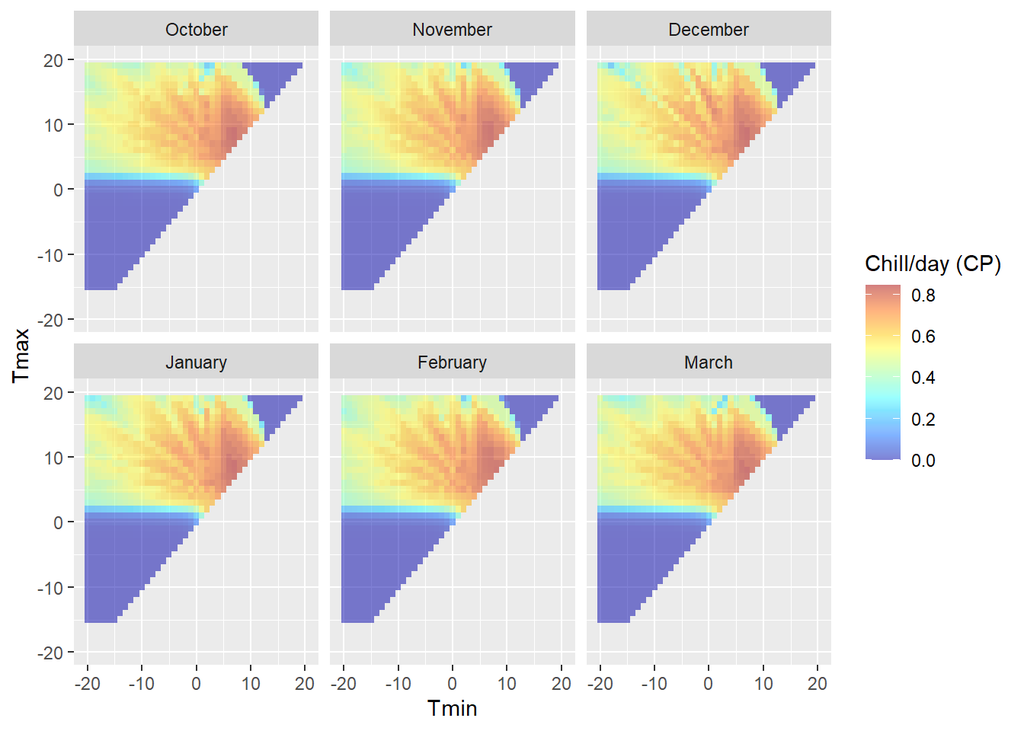

```r
DM_sensitivity <- DM_sensitivity +
  facet_wrap(vars(Month_names)) + # facet_wraps separates them by months
  ylim(min(results$Tmax),
       max(results$Tmax)) +
  ylim(min(results$Tmin),
       max(results$Tmin))
DM_sensitivity # nothing happens at -20 temp, at temp below freezing -10, we see some reactions,
```

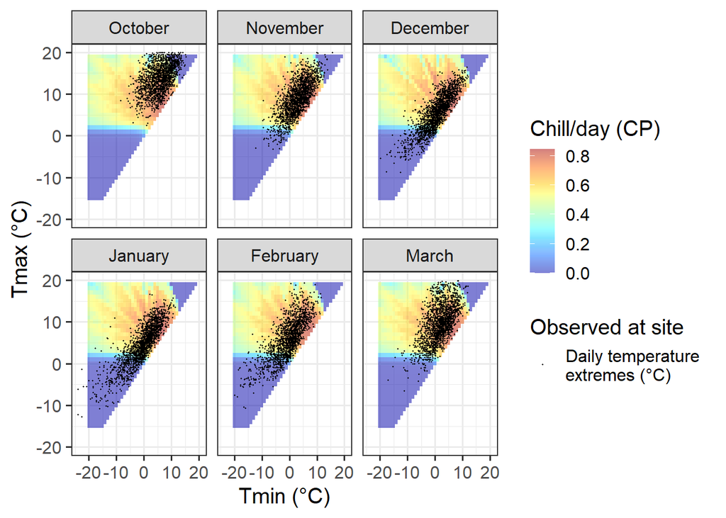

```r
temperatures <- read_tab("C:/Users/Home/Documents/R Files/Trial Bookdown/data_New_York/TMaxTMin1958-2019_patched.csv") %>%
  filter(Month %in% month_range) %>%
  mutate(Month_names =
           factor(Month,
                  levels = c(10, 11, 12, 1, 2, 3),
                  labels = c("October", "November", "December",
                             "January", "February", "March"))) #rename months

temperatures[which(temperatures$Tmax < temperatures$Tmin),
             c("Tmax", "Tmin")] <- NA

DM_sensitivity +
  geom_point(data = temperatures,
             aes(x = Tmin,
                 y = Tmax,
                 fill = NULL,
                 color = "Temperature"),
             size = 0.2) +
  facet_wrap(vars(Month_names)) +
  scale_color_manual(values = "black",
                     labels = "Daily temperature \nextremes (°C)",
                     name = "Observed at site" ) +
  guides(fill = guide_colorbar(order = 1),
         color = guide_legend(order = 2)) +
  ylab("Tmax (°C)") +
  xlab("Tmin (°C)") +
  theme_bw(base_size = 15) # Model response in relationship to temps observed in Rochester
```

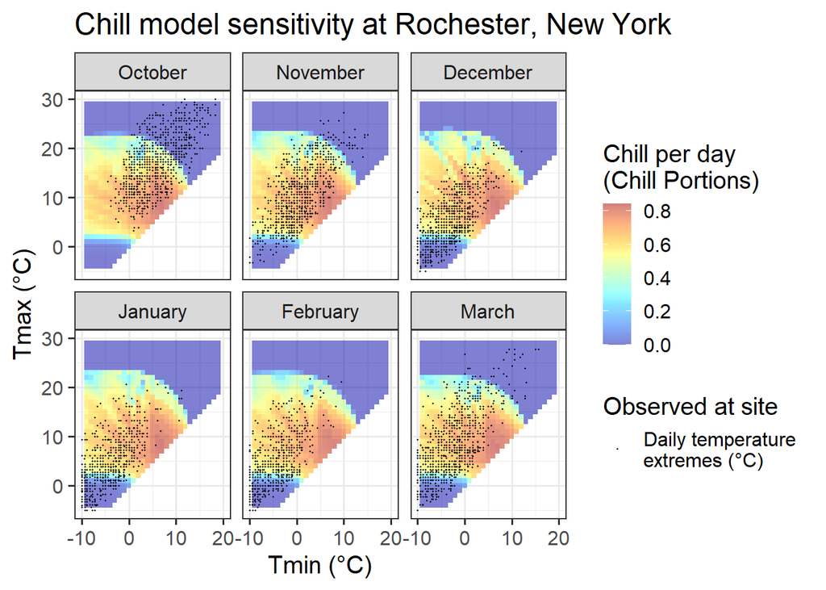

```r
Chill_model_sensitivity<- # creating a function for other locations
  function(latitude,
           temp_models = list(Dynamic_Model = Dynamic_Model,
                              GDH = GDH),
           month_range = c(10, 11, 12, 1, 2, 3),
           Tmins = c(-10:20),
           Tmaxs = c(-5:30))
  {
  mins <- NA
  maxs <- NA
  metrics <- as.list(rep(NA,
                         length(temp_models)))
  names(metrics) <- names(temp_models)
  month <- NA

  for(mon in month_range)
    {
    days_month <-
      as.numeric(difftime( ISOdate(2002,
                                   mon+1,
                                   1),
                           ISOdate(2002,
                                   mon,
                                   1) ))
    if(mon == 12) days_month <- 31
    weather <-
      make_all_day_table(data.frame(Year = c(2001, 2001),
                                    Month = c(mon, mon),
                                    Day = c(1, days_month),
                                    Tmin = c(0, 0),
                                    Tmax = c(0, 0)))


    for(tmin in Tmins)
      for(tmax in Tmaxs)
        if(tmax >= tmin)
          {
          hourtemps <- weather %>%
            mutate(Tmin = tmin,
                   Tmax = tmax) %>%
            stack_hourly_temps(
              latitude = latitude) %>%
            pluck("hourtemps",
                  "Temp")

          for(tm in 1:length(temp_models))
            metrics[[tm]] <-
              c(metrics[[tm]],
                tail(do.call(temp_models[[tm]],
                        list(hourtemps)),1)/
                  days_month)

          mins <- c(mins, tmin)
          maxs <- c(maxs, tmax)
          month <- c(month, mon)
        }
    }
  results <- cbind(data.frame(Month = month,
                              Tmin = mins,
                              Tmax = maxs),
                   as.data.frame(metrics))

  results <- results[!is.na(results$Month),]
}


Chill_sensitivity_temps <-
  function(chill_model_sensitivity_table,
           temperatures,
           temp_model,
           month_range = c(10, 11, 12, 1, 2, 3),
           Tmins = c(-10:20),
           Tmaxs = c(-5:30),
           legend_label = "Chill/day (CP)")
{
  library(ggplot2)
  library(colorRamps)

  cmst <- chill_model_sensitivity_table
  cmst <- cmst[which(cmst$Month %in% month_range),]
  cmst$Month_names <- factor(cmst$Month,
                             levels = month_range,
                             labels = month.name[month_range])

  DM_sensitivity<-
    ggplot(cmst,
           aes_string(x = "Tmin",
                      y = "Tmax",
                      fill = temp_model)) +
    geom_tile() +
    scale_fill_gradientn(colours = alpha(matlab.like(15),
                                         alpha = .5),
                         name = legend_label) +
    xlim(Tmins[1],
         Tmins[length(Tmins)]) +
    ylim(Tmaxs[1],
         Tmaxs[length(Tmaxs)])

  temperatures<-
    temperatures[which(temperatures$Month %in% month_range),]

  temperatures[which(temperatures$Tmax < temperatures$Tmin),
               c("Tmax",
                 "Tmin")] <- NA

  temperatures$Month_names <-
    factor(temperatures$Month,
           levels = month_range,
           labels = month.name[month_range])

  DM_sensitivity +
    geom_point(data = temperatures,
               aes(x = Tmin,
                   y = Tmax,
                   fill = NULL,
                   color = "Temperature"),
               size = 0.2) +
    facet_wrap(vars(Month_names)) +
    scale_color_manual(values = "black",
                       labels = "Daily temperature \nextremes (°C)",
                       name = "Observed at site" ) +
    guides(fill = guide_colorbar(order = 1),
           color = guide_legend(order = 2)) +
    ylab("Tmax (°C)") +
    xlab("Tmin (°C)") +
    theme_bw(base_size = 15)

}



Model_sensitivities_CNY <- # Rochester, New York
  Chill_model_sensitivity(latitude = 43,
                          temp_models = list(Dynamic_Model = Dynamic_Model,
                                             GDH = GDH),
                          month_range = c(10:12, 1:5))

write.csv(Model_sensitivities_CNY,
          "C:/Users/Home/Documents/R Files/Trial Bookdown/data_New_York/Model_sensitivities_CNY.csv",

          row.names = FALSE)


Model_sensitivities_CNY <- read.csv("C:/Users/Home/Documents/R Files/Trial Bookdown/data_New_York/Model_sensitivities_CNY.csv")

Rochester_weather <- read_tab("C:/Users/Home/Documents/R Files/Trial Bookdown/data_New_York/Rochester_weather.csv")

Chill_sensitivity_temps(Model_sensitivities_CNY,
                        Rochester_weather,
                        temp_model = "Dynamic_Model",
                        month_range = c(10, 11, 12, 1, 2, 3),
                        legend_label = "Chill per day \n(Chill Portions)") +
  ggtitle("Chill model sensitivity at Rochester, New York")
```

```r
#
Chill_sensitivity_temps(Model_sensitivities_CNY,
                        Rochester_weather,
                        temp_model = "GDH",
                        month_range = c(12, 1:5),
                        legend_label = "Heat per day \n(GDH)") +
  ggtitle("Heat model sensitivity at Rochester, New York")
```

[output not shown]

## 23.2

[figure not shown]

# 24 Chapter 26: Evaluating PLS outputs

## 24.1 *Exercises on expected PLS results*

1. Reproduce the analysis for the ‘Roter Boskoop’ dataset.

```r
library(chillR)
library(magrittr)
library(tidyverse)

Roter_first <- read_tab("C:/Users/Home/Documents/R Files/Trial Bookdown/data_New_York/Roter_Boskoop_bloom_1958_2019.csv.csv") %>%
  select(Pheno_year, First_bloom) %>%
  mutate(Year = as.numeric(substr(First_bloom, 1, 4)),
         Month = as.numeric(substr(First_bloom, 5, 6)),
         Day = as.numeric(substr(First_bloom, 7, 8))) %>%
  make_JDay() %>%
  select(Pheno_year,
         JDay) %>%
  rename(Year = Pheno_year,
         pheno = JDay)

temps <- read_tab("C:/Users/Home/Documents/R Files/Trial Bookdown/data_New_York/TMaxTMin1958-2019_patched.csv")

temps_hourly <- temps %>%
  stack_hourly_temps(latitude = 43.1)

daychill <- daily_chill(hourtemps = temps_hourly,
                        running_mean = 1,
                        models = list(Chilling_Hours = Chilling_Hours,
                                      Utah_Chill_Units = Utah_Model,
                                      Chill_Portions = Dynamic_Model,
                                      GDH = GDH)
                        )


plscf <- PLS_chill_force(daily_chill_obj = daychill,
                         bio_data_frame = Roter_first,
                         split_month = 6,
                         chill_models = "Chill_Portions",
                         heat_models = "GDH",
                         runn_means = 11)


library(ggplot2)
plot_PLS_chill_force <- function(plscf,
                                 chill_metric = "Chill_Portions",
                                 heat_metric = "GDH",
                                 chill_label = "CP",
                                 heat_label = "GDH",
                                 chill_phase = c(-48, 62),
                                 heat_phase = c(-5, 105.5))
{
  PLS_gg <- plscf[[chill_metric]][[heat_metric]]$PLS_summary %>%
    mutate(Month = trunc(Date/100),
           Day = Date - Month * 100,
           Date = ISOdate(2002,
                          Month,
                          Day))

  PLS_gg[PLS_gg$JDay <= 0,"Date"]<-
    ISOdate(2001,
            PLS_gg$Month[PLS_gg$JDay <= 0],
            PLS_gg$Day[PLS_gg$JDay <= 0])

  PLS_gg <- PLS_gg %>%
    mutate(VIP_importance = VIP >= 0.8,
           VIP_Coeff = factor(sign(Coef) * VIP_importance))

  chill_start_date <- ISOdate(2001,
                              12,
                              31) + chill_phase[1] * 24 * 3600
  chill_end_date <- ISOdate(2001,
                            12,
                            31) + chill_phase[2] * 24 * 3600
  heat_start_date <- ISOdate(2001,
                             12,
                             31) + heat_phase[1] * 24 * 3600
  heat_end_date <- ISOdate(2001,
                           12,
                           31) + heat_phase[2] * 24 * 3600




  temp_plot <- ggplot(PLS_gg) +
    annotate("rect",
             xmin = chill_start_date,
             xmax = chill_end_date,
             ymin = -Inf,
             ymax = Inf,
             alpha = .1,
             fill = "blue") +
    annotate("rect",
             xmin = heat_start_date,
             xmax = heat_end_date,
             ymin = -Inf,
             ymax = Inf,
             alpha = .1,
             fill = "red") +
    annotate("rect",
             xmin = ISOdate(2001,
                            12,
                            31) +
               min(plscf$pheno$pheno,
                   na.rm = TRUE) * 24 * 3600,
             xmax = ISOdate(2001,
                            12,
                            31) +
               max(plscf$pheno$pheno,
                   na.rm = TRUE) * 24 * 3600,
             ymin = -Inf,
             ymax = Inf,
             alpha = .1,
             fill = "black") +
    geom_vline(xintercept = ISOdate(2001,
                                    12,
                                    31) +
                 median(plscf$pheno$pheno,
                        na.rm=TRUE) * 24 * 3600,
               linetype = "dashed") +
    geom_ribbon(aes(x = Date,
                    ymin = MetricMean - MetricStdev ,
                    ymax = MetricMean + MetricStdev ),
                fill = "grey") +
    geom_ribbon(aes(x = Date,
                    ymin = MetricMean - MetricStdev * (VIP_Coeff == -1),
                    ymax = MetricMean + MetricStdev * (VIP_Coeff == -1)),
                fill = "red") +
    geom_ribbon(aes(x = Date,
                    ymin = MetricMean - MetricStdev * (VIP_Coeff == 1),
                    ymax = MetricMean + MetricStdev * (VIP_Coeff == 1)),
                fill = "dark green") +
    geom_line(aes(x = Date,
                  y = MetricMean)) +
    facet_wrap(vars(Type),
               scales = "free_y",
               strip.position = "left",
               labeller =
                 labeller(
                   Type =
                     as_labeller(c(Chill = paste0("Chill (",
                                                  chill_label,
                                                  ")"),
                                   Heat = paste0("Heat (",
                                                 heat_label,
                                                 ")"))))) +
    ggtitle("Daily chill and heat accumulation rates") +
    theme_bw(base_size = 15) +
    theme(strip.background = element_blank(),
          strip.placement = "outside",
          strip.text.y = element_text(size = 12),
          plot.title = element_text(hjust = 0.5),
          axis.title.y = element_blank()
          )

  VIP_plot <- ggplot(PLS_gg,
                     aes(x = Date,
                         y = VIP)) +
    annotate("rect",
             xmin = chill_start_date,
             xmax = chill_end_date,
             ymin = -Inf,
             ymax = Inf,
             alpha = .1,
             fill = "blue") +
    annotate("rect",
             xmin = heat_start_date,
             xmax = heat_end_date,
             ymin = -Inf,
             ymax = Inf,
             alpha = .1,
             fill = "red") +
    annotate("rect",
             xmin = ISOdate(2001,
                            12,
                            31) + min(plscf$pheno$pheno,
                                      na.rm = TRUE) * 24 * 3600,
             xmax = ISOdate(2001,
                            12,
                            31) + max(plscf$pheno$pheno,
                                      na.rm = TRUE) * 24 * 3600,
             ymin = -Inf,
             ymax = Inf,
             alpha = .1,
             fill = "black") +
    geom_vline(xintercept = ISOdate(2001,
                                    12,
                                    31) + median(plscf$pheno$pheno,
                                                 na.rm = TRUE) * 24 * 3600,
               linetype = "dashed") +
    geom_bar(stat = 'identity',
             aes(fill = VIP>0.8)) +
    facet_wrap(vars(Type),
               scales = "free",
               strip.position = "left",
               labeller =
                 labeller(
                   Type = as_labeller(c(Chill="VIP for chill",
                                        Heat="VIP for heat")))) +
    scale_y_continuous(
      limits = c(0,
                 max(plscf[[chill_metric]][[heat_metric]]$PLS_summary$VIP))) +
    ggtitle("Variable Importance in the Projection (VIP) scores") +
    theme_bw(base_size = 15) +
    theme(strip.background = element_blank(),
          strip.placement = "outside",
          strip.text.y = element_text(size = 12),
          plot.title = element_text(hjust = 0.5),
          axis.title.y = element_blank()
          ) +
    scale_fill_manual(name = "VIP",
                      labels = c("<0.8", ">0.8"),
                      values = c("FALSE" = "grey",
                                 "TRUE" = "blue")) +
    theme(axis.text.x = element_blank(),
          axis.ticks.x = element_blank(),
          axis.title.x = element_blank(),
          axis.title.y = element_blank())

  coeff_plot <- ggplot(PLS_gg,
                       aes(x = Date,
                           y = Coef)) +
    annotate("rect",
             xmin = chill_start_date,
             xmax = chill_end_date,
             ymin = -Inf,
             ymax = Inf,
             alpha = .1,
             fill = "blue") +
    annotate("rect",
             xmin = heat_start_date,
             xmax = heat_end_date,
             ymin = -Inf,
             ymax = Inf,
             alpha = .1,
             fill = "red") +
    annotate("rect",
             xmin = ISOdate(2001,
                            12,
                            31) + min(plscf$pheno$pheno,
                                      na.rm = TRUE) * 24 * 3600,
             xmax = ISOdate(2001,
                            12,
                            31) + max(plscf$pheno$pheno,
                                      na.rm = TRUE) * 24 * 3600,
             ymin = -Inf,
             ymax = Inf,
             alpha = .1,
             fill = "black") +
    geom_vline(xintercept = ISOdate(2001,
                                    12,
                                    31) + median(plscf$pheno$pheno,
                                                 na.rm = TRUE) * 24 * 3600,
               linetype = "dashed") +
    geom_bar(stat = 'identity',
             aes(fill = VIP_Coeff)) +
    facet_wrap(vars(Type),
               scales = "free",
               strip.position = "left",
               labeller =
                 labeller(
                   Type = as_labeller(c(Chill = "MC for chill",
                                        Heat = "MC for heat")))) +
    scale_y_continuous(
      limits = c(min(plscf[[chill_metric]][[heat_metric]]$PLS_summary$Coef),
                 max(plscf[[chill_metric]][[heat_metric]]$PLS_summary$Coef))) +
    ggtitle("Model coefficients (MC)") +
    theme_bw(base_size = 15) +
    theme(strip.background = element_blank(),
          strip.placement = "outside",
          strip.text.y = element_text(size = 12),
          plot.title = element_text(hjust = 0.5),
          axis.title.y = element_blank()
          ) +
    scale_fill_manual(name = "Effect direction",
                      labels = c("Advancing",
                                 "Unimportant",
                                 "Delaying"),
                      values = c("-1" = "red",
                                 "0" = "grey",
                                 "1" = "dark green")) +
    ylab("PLS coefficient") +
    theme(axis.text.x = element_blank(),
          axis.ticks.x = element_blank(),
          axis.title.x = element_blank(),
          axis.title.y = element_blank())

  library(patchwork)

  plot <- (VIP_plot +
             coeff_plot +
             temp_plot +
             plot_layout(ncol = 1,
                         guides = "collect")
           ) & theme(legend.position = "right",
                     legend.text = element_text(size = 8),
                     legend.title = element_text(size = 10),
                     axis.title.x = element_blank())

plot

}




plot_PLS_chill_force(plscf,
                     chill_metric = "Chill_Portions",
                     heat_metric = "GDH",
                     chill_label = "CP",
                     heat_label = "GDH",
                     chill_phase = c(-48, 62),
                     heat_phase = c(-5, 105.5))
```

[output not shown]

```r
chill_phase <- c(317, 62)
heat_phase <- c(360, 105.5)

chill <- tempResponse(hourtemps = temps_hourly,
                      Start_JDay = chill_phase[1],
                      End_JDay = chill_phase[2],
                      models = list(Chill_Portions = Dynamic_Model),
                      misstolerance = 10)

heat <- tempResponse(hourtemps = temps_hourly,
                     Start_JDay = heat_phase[1],
                     End_JDay = heat_phase[2],
                     models = list(GDH = GDH))


ggplot(data = chill,
       aes(x = Chill_Portions)) +
  geom_histogram() +
  ggtitle("Chill accumulation during endodormancy (Chill Portions)") +
  xlab("Chill accumulation (Chill Portions)") +
  ylab("Frequency between 1958 and 2019") +
  theme_bw(base_size = 12)

ggplot(data = heat,
       aes(x = GDH)) +
  geom_histogram() +
  ggtitle("Heat accumulation during ecodormancy (GDH)") +
  xlab("Heat accumulation (Growing Degree Hours)") +
  ylab("Frequency between 1958 and 2019") +
  theme_bw(base_size = 12)


chill_requirement <- mean(chill$Chill_Portions)
chill_req_error <- sd(chill$Chill_Portions)

chill_nonpara <- quantile(chill$Chill_Portions,
                          c(0.05, 0.5, 0.95))

heat_requirement <- mean(heat$GDH)
heat_req_error <- sd(heat$GDH)

heat_nonpara <- quantile(heat$GDH,
                          c(0.05, 0.5, 0.95))

chill_phase <- c(317, 62)
heat_phase <- c(360, 106)


mpt <- make_pheno_trend_plot(weather_data_frame = temps,
                             pheno = Roter_first,
                             Start_JDay_chill = chill_phase[1],
                             End_JDay_chill = chill_phase[2],
                             Start_JDay_heat = heat_phase[1],
                             End_JDay_heat = heat_phase[2],
                             outpath = "data/",
                             file_name = "pheno_trend_plot",
                             plot_title =  "Impacts of chilling and forcing temperatures on pear phenology",
                             image_type = "png",
                             colorscheme = "normal")


mean_temp_period <- function(
    temps,
    start_JDay,
    end_JDay,
    end_season = end_JDay)
{ temps_JDay <- make_JDay(temps) %>%
  mutate(Season =Year)

  if(start_JDay > end_season)
    temps_JDay$Season[which(temps_JDay$JDay >= start_JDay)]<-
        temps_JDay$Year[which(temps_JDay$JDay >= start_JDay)]+1

  if(start_JDay > end_season)
    sub_temps <- subset(temps_JDay,
                        JDay <= end_JDay | JDay >= start_JDay)

  if(start_JDay <= end_JDay)
    sub_temps <- subset(temps_JDay,
                        JDay <= end_JDay & JDay >= start_JDay)

  mean_temps <- aggregate(sub_temps[, c("Tmin", "Tmax")],
                          by = list(sub_temps$Season),
                          FUN = function(x) mean(x,
                                                 na.rm=TRUE))

  mean_temps[, "n_days"] <- aggregate(sub_temps[, "Tmin"],
                                      by = list(sub_temps$Season),
                                      FUN = length)[,2]

  mean_temps[, "Tmean"] <- (mean_temps$Tmin + mean_temps$Tmax) / 2
  mean_temps <- mean_temps[, c(1, 4, 2, 3, 5)]
  colnames(mean_temps)[1] <- "End_year"

  return(mean_temps)
}

mean_temp_chill <- mean_temp_period(temps = temps,
                                    start_JDay = chill_phase[1],
                                    end_JDay = chill_phase[2],
                                    end_season = 60)

mean_temp_heat <- mean_temp_period(temps = temps,
                                   start_JDay = heat_phase[1],
                                   end_JDay = heat_phase[2],
                                   end_season = 60)


mean_temp_chill <-
  mean_temp_chill[which(mean_temp_chill$n_days >=
                          max(mean_temp_chill$n_days)-1),]
mean_temp_heat <-
  mean_temp_heat[which(mean_temp_heat$n_days >=
                         max(mean_temp_heat$n_days)-1),]

mean_chill <- mean_temp_chill[, c("End_year",
                                  "Tmean")]
colnames(mean_chill)[2] <- "Tmean_chill"

mean_heat <- mean_temp_heat[,c("End_year",
                               "Tmean")]
colnames(mean_heat)[2] <- "Tmean_heat"

phase_Tmeans <- merge(mean_chill,
                      mean_heat,
                      by = "End_year")


pheno <- Roter_first
colnames(pheno)[1] <- "End_year"

Tmeans_pheno <- merge(phase_Tmeans,
                      pheno,
                      by = "End_year")


head(Tmeans_pheno)



library(fields)
k <- Krig(x = as.matrix(
                Tmeans_pheno[,
                             c("Tmean_chill",
                               "Tmean_heat")]),
          Y = Tmeans_pheno$pheno)

pred <- predictSurface(k)
colnames(pred$z) <- pred$y
rownames(pred$z) <- pred$x

library(reshape2)
melted <- melt(pred$z)

library(metR)
library(colorRamps)

colnames(melted) <- c("Tmean_chill",
                      "Tmean_heat",
                      "value")


ggplot(melted,
       aes(x = Tmean_chill,
           y = Tmean_heat,
           z = value)) +
  geom_contour_fill(bins = 100) +
  scale_fill_gradientn(colours = alpha(matlab.like(15)),
                       name = "Bloom date \n(day of the year)") +
  geom_contour(col = "black")  +
  geom_point(data = Tmeans_pheno,
             aes(x = Tmean_chill,
                 y = Tmean_heat,
                 z = NULL),
             size = 0.7) +
  geom_text_contour(stroke = 0.2) +
  ylab(expression(paste("Forcing phase ",
                        T[mean],
                        " (",
                        degree,
                        "C)"))) +
  xlab(expression(paste("Chilling phase ",
                        T[mean],
                        " (",
                        degree,
                        "C)")))  +
  theme_bw(base_size = 15)






pheno_trend_ggplot <- function(temps,
                               pheno,
                               chill_phase,
                               heat_phase,
                               phenology_stage = "Bloom")
{
  library(fields)
  library(reshape2)
  library(metR)
  library(ggplot2)
  library(colorRamps)
```

[output not shown]

```r
  mean_temp_period <- function(temps,
                               start_JDay,
                               end_JDay,
                               end_season = end_JDay)
    { temps_JDay <- make_JDay(temps) %>%
      mutate(Season = Year)

    if(start_JDay > end_season)
      temps_JDay$Season[which(temps_JDay$JDay >= start_JDay)] <-
        temps_JDay$Year[which(temps_JDay$JDay >= start_JDay)]+1

    if(start_JDay > end_season)
      sub_temps <- subset(temps_JDay,
                          JDay <= end_JDay | JDay >= start_JDay)

    if(start_JDay <= end_JDay)
      sub_temps <- subset(temps_JDay,
                          JDay <= end_JDay & JDay >= start_JDay)

    mean_temps <- aggregate(sub_temps[,
                                      c("Tmin",
                                        "Tmax")],
                            by = list(sub_temps$Season),
                            FUN = function(x) mean(x,
                                                   na.rm = TRUE))
    mean_temps[, "n_days"] <- aggregate(sub_temps[,
                                                  "Tmin"],
                                        by = list(sub_temps$Season),
                                        FUN = length)[,2]

    mean_temps[,"Tmean"] <- (mean_temps$Tmin + mean_temps$Tmax) / 2
    mean_temps <- mean_temps[, c(1, 4, 2, 3, 5)]
    colnames(mean_temps)[1] <- "End_year"
    return(mean_temps)
    }

  mean_temp_chill <- mean_temp_period(temps = temps,
                                      start_JDay = chill_phase[1],
                                      end_JDay = chill_phase[2],
                                      end_season = heat_phase[2])

  mean_temp_heat <- mean_temp_period(temps = temps,
                                     start_JDay = heat_phase[1],
                                     end_JDay = heat_phase[2],
                                     end_season = heat_phase[2])

  mean_temp_chill <-
    mean_temp_chill[which(mean_temp_chill$n_days >=
                            max(mean_temp_chill$n_days)-1),]
  mean_temp_heat <-
    mean_temp_heat[which(mean_temp_heat$n_days >=
                           max(mean_temp_heat$n_days)-1),]
  mean_chill <- mean_temp_chill[, c("End_year",
                                    "Tmean")]
  colnames(mean_chill)[2] <- "Tmean_chill"
  mean_heat<-mean_temp_heat[,c("End_year",
                               "Tmean")]
  colnames(mean_heat)[2] <- "Tmean_heat"
  phase_Tmeans <- merge(mean_chill,
                        mean_heat,
                        by = "End_year")

  colnames(pheno) <- c("End_year",
                       "pheno")
  Tmeans_pheno <- merge(phase_Tmeans,
                        pheno,
                        by="End_year")

  # Kriging interpolation
  k <- Krig(x = as.matrix(Tmeans_pheno[,c("Tmean_chill",
                                          "Tmean_heat")]),
            Y = Tmeans_pheno$pheno)
  pred <- predictSurface(k)
  colnames(pred$z) <- pred$y
  rownames(pred$z) <- pred$x
  melted <- melt(pred$z)
  colnames(melted) <- c("Tmean_chill",
                        "Tmean_heat",
                        "value")

  ggplot(melted,
         aes(x = Tmean_chill,
             y = Tmean_heat,
             z = value)) +
    geom_contour_fill(bins = 60) +
    scale_fill_gradientn(colours = alpha(matlab.like(15)),
                         name = paste(phenology_stage,
                                      "date \n(day of the year)")) +
    geom_contour(col = "black") +
    geom_text_contour(stroke = 0.2) +
    geom_point(data = Tmeans_pheno,
               aes(x = Tmean_chill,
                   y = Tmean_heat,
                   z = NULL),
               size = 0.7)  +
    ylab(expression(paste("Forcing phase ",
                          T[mean],
                          " (",
                          degree,
                          "C)"))) +
    xlab(expression(paste("Chilling phase ",
                          T[mean],
                          " (",
                          degree,
                          "C)"))) +
    theme_bw(base_size = 15)
}


chill_phase <- c(317, 62)
heat_phase <- c(360, 105.5)

pheno_trend_ggplot(temps = temps,
                   pheno = Roter_first,
                   chill_phase = chill_phase,
                   heat_phase = heat_phase,
                   phenology_stage = "Bloom")

# Applying to california
# Cali_temps <- read_tab("data/Davis_weather.csv")
# Walnut_pheno <- read_tab("data/Davis_Payne_leaf_out.csv") %>%
#   mutate(Year = as.numeric(substr(Leaf.date,7,8)),
#          Year = Year+(19+(Year<25))*100,
#          Month = as.numeric(substr(Leaf.date,4,5)),
#          Day = as.numeric(substr(Leaf.date,1,2))) %>%
#   make_JDay() %>%
#   select(Year, JDay)
#
# colnames(Walnut_pheno) <- c("Year",
#                             "pheno")
#
# Cali_temps_hourly <- stack_hourly_temps(Cali_temps,
#                                         latitude = 38.5)
#
# Cali_daychill <- daily_chill(hourtemps = Cali_temps_hourly,
#                              running_mean = 1,
#                              models = list(Chilling_Hours = Chilling_Hours,
#                                            Utah_Chill_Units = Utah_Model,
#                                            Chill_Portions = Dynamic_Model,
#                                            GDH = GDH)
#     )
#
#
# plscf <- PLS_chill_force(daily_chill_obj = Cali_daychill,
#                          bio_data_frame = Walnut_pheno,
#                          split_month = 6,
#                          chill_models = "Chill_Portions",
#                          heat_models = "GDH",
#                          runn_means = 11)
#
# plot_PLS_chill_force(plscf,
#                      chill_metric = "Chill_Portions",
#                      heat_metric = "GDH",
#                      chill_label = "CP",
#                      heat_label = "GDH",
#                      chill_phase = c(-56, 5),
#                      heat_phase = c(19, 77))
#
# pheno_trend_ggplot(temps = Cali_temps,
#                    pheno = Walnut_pheno,
#                    chill_phase = c(309, 5),
#                    heat_phase = c(19, 77),
#                    phenology_stage = "Leaf emergence")
#
```

[output not shown]

2.We’ve looked at data from a number of locations so far. How would you expect this surface plot to look like in Beijing? And how should it look in Tunisia?

# 25 Chapter 27: The relative importance of chill and heat

## 25.1 *Exercises on the relative importance of chill and heat*

Describe the temperature response hypothesis outlined in this chapter.

The temperature response hypothesis explains how the phenology of temperate trees in cold-winter climates responds to temperature variations during the chilling and forcing periods. During the ecodormancy phase, when buds are sensitive to heat, spring phenology is primarily influenced by forcing temperatures, as chill accumulation in such climates is usually high, and winter conditions are favorable for chilling. This stability makes it challenging to define the chilling period in these regions.

As endodormancy temperatures rise, temperature conditions during chill accumulation begin to influence phenology, introducing a delaying effect. This transition is marked by increasing interaction between chill and forcing temperatures, depicted as upward-bending contour lines in the hypothesis framework. With further warming, chilling temperatures dominate, eventually causing stagnation or delays in budbreak, instead of advancing phenology.

# 26 Chapter 29: Making valid tree phenology models

## 26.1 *Exercises on making valid tree phenology models*

1. Explain the difference between output validation and process validation.

Output validation assesses a model’s predictive accuracy, while process validation ensures the model’s internal logic is scientifically sound and reflective of real-world processes. For instance, output validation relies on performance metrics like Root Mean Square Error (RMSE) or Model Efficiency to quantify accuracy while requires domain knowledge about the processes to evaluate how well the model represents them. Both are important, but process validation provides deeper confidence in the model’s applicability beyond specific datasets.

2. Explain what a validity domain is and why it is important to consider this whenever we want to use our model to forecast something.This is the range of conditions that the model is capable of making reliable predictions for.

Validity domain ensures that models are applied within their appropriate scope, enhancing their reliability and relevance. In application, model performance to be validated under conditions that resemble those predicted.

3. What is validation for purpose?

Validation for purpose is the process of assessing whether a model is capable of achieving its intended objective in a specific context. It involves reflecting on the model’s goals and evaluating if it can realistically and reliably deliver the required predictions under the conditions of interest. This approach considers the model’s assumptions, structure, and data inputs to determine its applicability for a given task.

4. How can we ensure that our model is suitable for the predictions we want to make?

We must verify that the predictions we wish to make come inside the model’s validity domain, meaning that the requirements for making those predictions closely match the set of requirements that the model is predicated on, in order to make sure our model is appropriate for those predictions. Additionally, there are instances in which model predictions may remain accurate even when they are outside the model’s validity domain. The model can still be considered appropriate in certain situations, but it needs to be strongly justified.

# 27 Chapter 30: The Phenoflex Model

## 27.1 *Exercises on making valid tree phenology models*

1. Parameterize the PhenoFlex model for `Roter Boskoop’ apples.

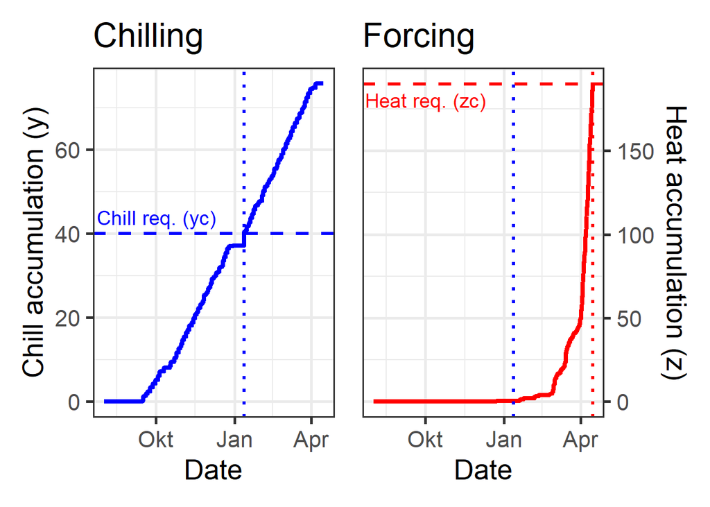

```r
library(chillR)
library(ggplot2)
library(tidyverse)

CKA_weather <- read_tab("C:/Users/Home/Documents/R Files/Trial Bookdown/data_New_York/TMaxTMin1958-2019_patched.csv")
hourtemps <- stack_hourly_temps(CKA_weather,
                                latitude = 50.6)

yc <- 40 # chilling requirement
zc <- 190 # heating requirement

iSeason <- genSeason(hourtemps,
                     mrange = c(8, 6), # month range
                     years = c(2009))

season_data <- hourtemps$hourtemps[iSeason[[1]],]

res <- PhenoFlex(temp = season_data$Temp,
                 times = c(1: length(season_data$Temp)),
                 zc = zc,
                 stopatzc = TRUE,
                 yc = yc,
                 basic_output = FALSE)

DBreakDay <- res$bloomindex
seasontemps <- hourtemps$hourtemps[iSeason[[1]],]
seasontemps[,"x"] <- res$x
seasontemps[,"y"] <- res$y
seasontemps[,"z"] <- res$z
seasontemps <- add_date(seasontemps)

CR_full <- seasontemps$Date[which(seasontemps$y >= yc)[1]] # the date where chilling requirement is broken
Bloom <- seasontemps$Date[which(seasontemps$z >= zc)[1]]

chillplot <- ggplot(data = seasontemps[1:DBreakDay,],
                    aes(x = Date,
                        y = y)) +
  geom_line(col = "blue",
            lwd = 1.5) +
  theme_bw(base_size = 20) +
  geom_hline(yintercept = yc,
             lty = 2,
             col = "blue",
             lwd = 1.2) +
  geom_vline(xintercept = CR_full,
             lty = 3,
             col = "blue",
             lwd = 1.2) +
  ylab("Chill accumulation (y)") +
  labs(title = "Chilling") +
  annotate("text",
           label = "Chill req. (yc)",
           x = ISOdate(2008,10,01),
           y = yc*1.1,
           col = "blue",
           size = 5)

heatplot <- ggplot(data = seasontemps[1:DBreakDay,],
                   aes(x = Date,
                       y = z)) +
  geom_line(col = "red",
            lwd = 1.5) +
  theme_bw(base_size = 20) +
  scale_y_continuous(position = "right") +
  geom_hline(yintercept = zc,
             lty = 2,
             col = "red",
             lwd = 1.2) +
  geom_vline(xintercept = CR_full,
             lty = 3,
             col = "blue",
             lwd = 1.2) +
  geom_vline(xintercept = Bloom,
             lty = 3,
             col = "red",
             lwd = 1.2) +
  ylab("Heat accumulation (z)") +
  labs(title = "Forcing") +
  annotate("text",
           label = "Heat req. (zc)",
           x = ISOdate(2008,10,01),
           y = zc*0.95,
           col = "red",
           size = 5)


library(patchwork)
chillplot + heatplot
```

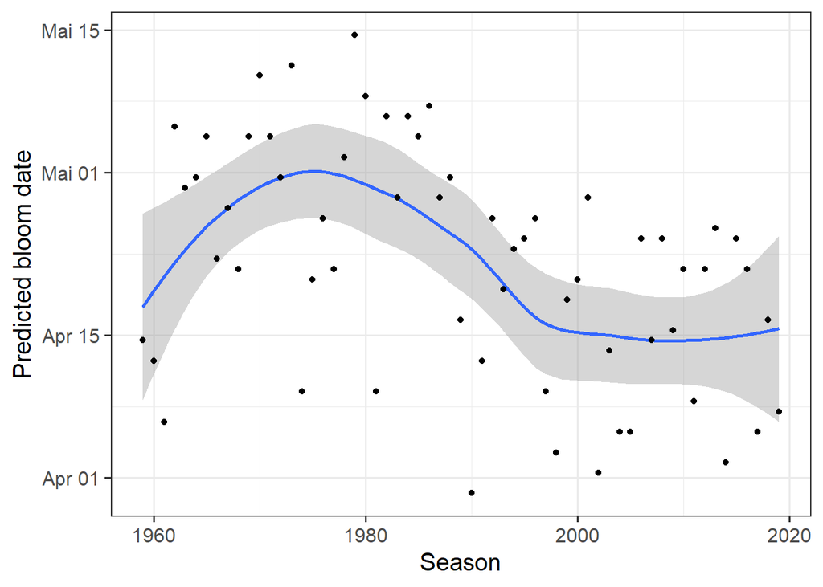

```r
yc <- 40
zc <- 190
seasons <- 1959:2019

iSeason <- genSeason(hourtemps,
                     mrange = c(8, 6),
                     years = seasons)

for (sea in 1:length(seasons))
{season_data <- hourtemps$hourtemps[iSeason[[sea]], ]
 res <- PhenoFlex(temp = season_data$Temp,
                  times = c(1: length(season_data$Temp)),
                  zc = zc,
                  stopatzc = TRUE,
                  yc = yc,
                  basic_output = FALSE)
 if(sea == 1)
    results <- season_data$DATE[res$bloomindex] else
      results <- c(results,
                   season_data$DATE[res$bloomindex])}

predictions <- data.frame(Season = seasons,
                          Prediction = results)
predictions$Prediction <-
  ISOdate(2001,
          substr(predictions$Prediction, 4, 5),
          substr(predictions$Prediction, 1, 2))

ggplot(data = predictions,
       aes(x = Season,
           y = Prediction)) +
  geom_smooth() +
  geom_point() +
  ylab("Predicted bloom date") +
  theme_bw(base_size = 15)
```

```r
Roter_first <- read_tab("C:/Users/Home/Documents/R Files/Trial Bookdown/data_New_York/Roter_Boskoop_bloom_1958_2019.csv.csv") %>%
  select(Pheno_year, First_bloom) %>%
  mutate(Year = as.numeric(substr(First_bloom, 1, 4)),
         Month = as.numeric(substr(First_bloom, 5, 6)),
         Day = as.numeric(substr(First_bloom, 7, 8))) %>%
  make_JDay() %>%
  select(Pheno_year, JDay) %>%
  rename(Year = Pheno_year,
         pheno = JDay)

hourtemps <-
  read_tab("C:/Users/Home/Documents/R Files/Trial Bookdown/data_New_York/TMaxTMin1958-2019_patched.csv") %>%
  stack_hourly_temps(latitude = 50.6)


# here's the order of the parameters (from the helpfile of the
# PhenoFlex_GDHwrapper function)
#          yc,  zc,  s1, Tu,    E0,      E1,     A0,         A1,   Tf, Tc, Tb,  slope

par <-   c(40, 190, 0.5, 25, 3372.8,  9900.3, 6319.5,
           5.939917e13,  4, 36,  4,  1.60)
upper <- c(41, 200, 1.0, 30, 4000.0, 10000.0, 7000.0,
           6.e13, 10, 40, 10, 50.00)
lower <- c(38, 180, 0.1, 0 , 3000.0,  9000.0, 6000.0,
           5.e13,  0,  0,  0,  0.05)

SeasonList <- genSeasonList(hourtemps$hourtemps,
                            mrange = c(8, 6),
                            years = c(1959:2018))

Fit_res <-
  phenologyFitter(par.guess = par,
                  modelfn = PhenoFlex_GDHwrapper,
                  bloomJDays = Roter_first$pheno[which(Roter_first$Year > 1958)],
                  SeasonList = SeasonList,
                  lower = lower,
                           upper = upper,
                           control = list(smooth = FALSE,
                                          verbose = FALSE,
                                          maxit = 1000,
                                          nb.stop.improvement = 5))
Roter_par <- Fit_res$par

write.csv(Roter_par,
          "C:/Users/Home/Documents/R Files/Trial Bookdown/data_New_York/PhenoFlex_parameters_Roter_Boskoop.csv")

kable(head(Roter_par)) %>%
  kable_styling("striped", position = "left", font_size = 10)
```

| x |
| --- |
| 39.4579019 |
| 195.5517993 |
| 0.3217589 |
| 25.0000000 |
| 3372.8000000 |
| 9900.3000000 |

2. Produce plots of predicted vs. observed bloom dates and distribution of prediction errors.

```r
library(chillR)
library(ggplot2)
library(tidyverse)

Roter_par <-
  read_tab("C:/Users/Home/Documents/R Files/Trial Bookdown/data_New_York/PhenoFlex_parameters_Roter_Boskoop.csv")[,2]

SeasonList <- genSeasonList(hourtemps$hourtemps,
                            mrange = c(8, 6),
                            years = c(1959:2018))

Roter_PhenoFlex_predictions <- Roter_first[which(Roter_first$Year > 1958),]

for(y in 1:length(Roter_PhenoFlex_predictions$Year))
   Roter_PhenoFlex_predictions$predicted[y] <-
    PhenoFlex_GDHwrapper(SeasonList[[y]],
                         Roter_par)

Roter_PhenoFlex_predictions$Error <-
  Roter_PhenoFlex_predictions$predicted -
  Roter_PhenoFlex_predictions$pheno

RMSEP(Roter_PhenoFlex_predictions$predicted,
      Roter_PhenoFlex_predictions$pheno)
```

```
## [1] 4.690369
```

```r
mean(Roter_PhenoFlex_predictions$Error)
```

```
## [1] -1.915972
```

```r
mean(abs(Roter_PhenoFlex_predictions$Error))
```

```
## [1] 3.340972
```

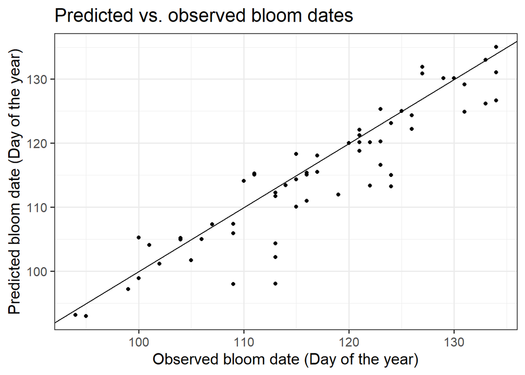

```r
ggplot(Roter_PhenoFlex_predictions,
       aes(x = pheno,
           y = predicted)) +
  geom_point() +
  geom_abline(intercept = 0,
              slope = 1) +
  theme_bw(base_size = 15) +
  xlab("Observed bloom date (Day of the year)") +
  ylab("Predicted bloom date (Day of the year)") +
  ggtitle("Predicted vs. observed bloom dates")
```

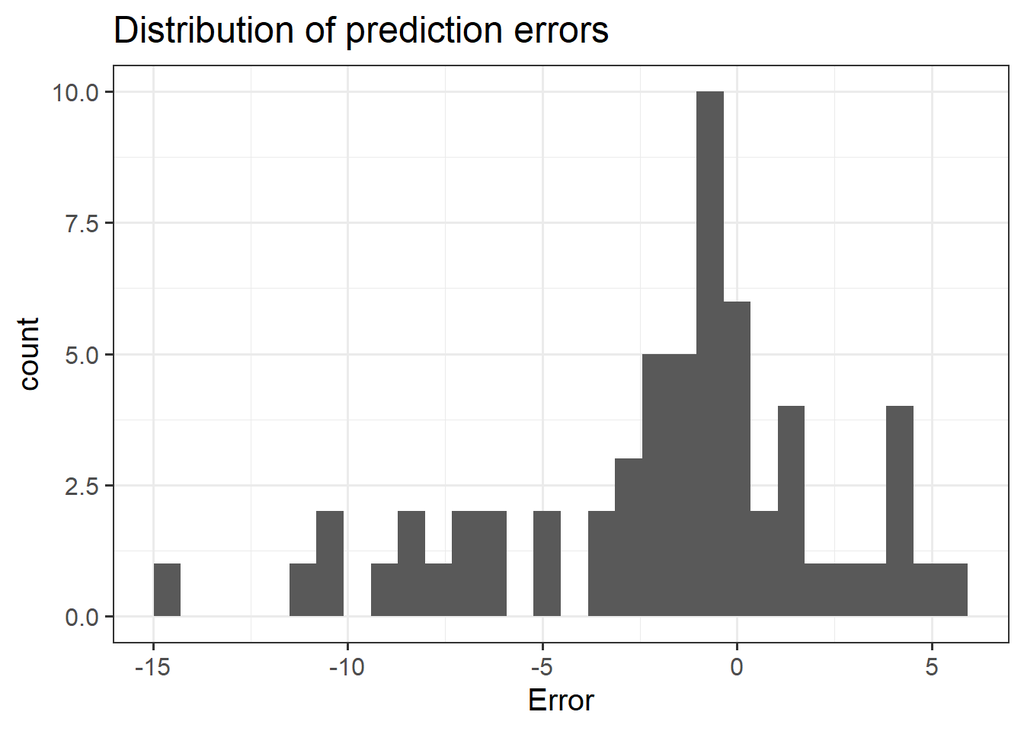

```r
ggplot(Roter_PhenoFlex_predictions,
       aes(Error)) +
  geom_histogram() +
  ggtitle("Distribution of prediction errors") +
  theme_bw(base_size = 15)
```

3. Compute the model performance metrics RMSEP, mean error and mean absolute error.

```r
RMSEP <- chillR::RMSEP(Roter_PhenoFlex_predictions$predicted, Roter_PhenoFlex_predictions$pheno)

mean <- mean(Roter_PhenoFlex_predictions$Error)

abs_mean <- mean(abs(Roter_PhenoFlex_predictions$Error))

result <- data.frame(RMSEP = RMSEP, Mean = mean, `Absolute Mean` = abs_mean, check.names = FALSE)


kable(result) %>%
    kable_styling("striped", position = "left", font_size = 10)
```

| RMSEP | Mean | Absolute Mean |
| --- | --- | --- |
| 4.69037 | -1.915972 | 3.340972 |